# Data Wrangling

- Gather
- Assess
- Notes
- Clean

```python
# import the needed libraries
import pandas as pd
import numpy as np
import requests
import zipfile
import matplotlib.pyplot as plt
from pandas.plotting import register_matplotlib_converters
register_matplotlib_converters()
import seaborn as sns
plt.style.use('bmh')
from PIL import Image
from io import BytesIO
from wordcloud import WordCloud, STOPWORDS
import requests
import numpy as np
%matplotlib inline
```

## Gather

```python
# read the provided csv file twitter-archive-enhanced file (file on hand) and save it
twitter_archive = pd.read_csv('twitter-archive-enhanced.csv')
```

```python
# read the first 5 rows for data inspection
twitter_archive.head()
```

|  | tweet_id | in_reply_to_status_id | in_reply_to_user_id | timestamp | source | text | retweeted_status_id | retweeted_status_user_id | retweeted_status_timestamp | expanded_urls | rating_numerator | rating_denominator | name | doggo | floofer | pupper | puppo |
| --- | --- | --- | --- | --- | --- | --- | --- | --- | --- | --- | --- | --- | --- | --- | --- | --- | --- |
| 0 | 892420643555336193 | NaN | NaN | 2017-08-01 16:23:56 +0000 | <a href="http://twitter.com/download/iphone" r... | This is Phineas. He's a mystical boy. Only eve... | NaN | NaN | NaN | https://twitter.com/dog_rates/status/892420643... | 13 | 10 | Phineas | None | None | None | None |
| 1 | 892177421306343426 | NaN | NaN | 2017-08-01 00:17:27 +0000 | <a href="http://twitter.com/download/iphone" r... | This is Tilly. She's just checking pup on you.... | NaN | NaN | NaN | https://twitter.com/dog_rates/status/892177421... | 13 | 10 | Tilly | None | None | None | None |
| 2 | 891815181378084864 | NaN | NaN | 2017-07-31 00:18:03 +0000 | <a href="http://twitter.com/download/iphone" r... | This is Archie. He is a rare Norwegian Pouncin... | NaN | NaN | NaN | https://twitter.com/dog_rates/status/891815181... | 12 | 10 | Archie | None | None | None | None |
| 3 | 891689557279858688 | NaN | NaN | 2017-07-30 15:58:51 +0000 | <a href="http://twitter.com/download/iphone" r... | This is Darla. She commenced a snooze mid meal... | NaN | NaN | NaN | https://twitter.com/dog_rates/status/891689557... | 13 | 10 | Darla | None | None | None | None |
| 4 | 891327558926688256 | NaN | NaN | 2017-07-29 16:00:24 +0000 | <a href="http://twitter.com/download/iphone" r... | This is Franklin. He would like you to stop ca... | NaN | NaN | NaN | https://twitter.com/dog_rates/status/891327558... | 12 | 10 | Franklin | None | None | None | None |

```python
# getting the image prediction file programmatically  using the given url
url = 'https://d17h27t6h515a5.cloudfront.net/topher/2017/August/599fd2ad_image-predictions/image-predictions.tsv'
response = requests.get(url)

# save to .tsv file
with open('image_predictions.tsv', 'wb') as file:
    file.write(response.content)
```

```python
# read the image prediction file and save to pandas DataFrame
image_pred = pd.read_csv('image_predictions.tsv',sep='\t')

# check for the data top 5 rows
image_pred.head()
```

|  | tweet_id | jpg_url | img_num | p1 | p1_conf | p1_dog | p2 | p2_conf | p2_dog | p3 | p3_conf | p3_dog |
| --- | --- | --- | --- | --- | --- | --- | --- | --- | --- | --- | --- | --- |
| 0 | 666020888022790149 | https://pbs.twimg.com/media/CT4udn0WwAA0aMy.jpg | 1 | Welsh_springer_spaniel | 0.465074 | True | collie | 0.156665 | True | Shetland_sheepdog | 0.061428 | True |
| 1 | 666029285002620928 | https://pbs.twimg.com/media/CT42GRgUYAA5iDo.jpg | 1 | redbone | 0.506826 | True | miniature_pinscher | 0.074192 | True | Rhodesian_ridgeback | 0.072010 | True |
| 2 | 666033412701032449 | https://pbs.twimg.com/media/CT4521TWwAEvMyu.jpg | 1 | German_shepherd | 0.596461 | True | malinois | 0.138584 | True | bloodhound | 0.116197 | True |
| 3 | 666044226329800704 | https://pbs.twimg.com/media/CT5Dr8HUEAA-lEu.jpg | 1 | Rhodesian_ridgeback | 0.408143 | True | redbone | 0.360687 | True | miniature_pinscher | 0.222752 | True |
| 4 | 666049248165822465 | https://pbs.twimg.com/media/CT5IQmsXIAAKY4A.jpg | 1 | miniature_pinscher | 0.560311 | True | Rottweiler | 0.243682 | True | Doberman | 0.154629 | True |

*I tried to set up a twitter developer account, but my application was **not approved***.

- The following code is the Twitter API code supported by Udacity.
- So, I will *comment* it as a matter of reproducibilty when rerun all the code cells in this Jupyter notebook.

```python
# Query Twitter API for each tweet in the Twitter archive and save JSON in a text file
# These are hidden to comply with Twitter's API terms and conditions
#consumer_key = 'HIDDEN'
#consumer_secret = 'HIDDEN'
#access_token = 'HIDDEN'
#access_secret = 'HIDDEN'

#auth = OAuthHandler(consumer_key, consumer_secret)
#auth.set_access_token(access_token, access_secret)

#api = tweepy.API(auth, wait_on_rate_limit=True)


# NOTE TO REVIEWER: this student had mobile verification issues so the following
# Twitter API code was sent to this student from a Udacity instructor

# Tweet IDs for which to gather additional data via Twitter's API
#tweet_ids = twitter_archive.tweet_id.values
#len(tweet_ids)

# Query Twitter's API for JSON data for each tweet ID in the Twitter archive
#count = 0
#fails_dict = {}
#start = timer()
# Save each tweet's returned JSON as a new line in a .txt file
#with open('tweet_json.txt', 'w') as outfile:
    # This loop will likely take 20-30 minutes to run because of Twitter's rate limit
#    for tweet_id in tweet_ids:
#        count += 1
#        print(str(count) + ": " + str(tweet_id))
#        try:
#            tweet = api.get_status(tweet_id, tweet_mode='extended')
#            print("Success")
#            json.dump(tweet._json, outfile)
#            outfile.write('\n')
#        except tweepy.TweepError as e:
#            print("Fail")
#            fails_dict[tweet_id] = e
#            pass
#end = timer()
#print(end - start)
#print(fails_dict)
```

The data that should be gathered by the previous code is supported in the project resources by Udacity as **zip file**.

```python
# extract the file from the zipfile
with open('tweet-json.zip','rb') as f:
    z_tweets = zipfile.ZipFile(f)
    z_tweets.extractall()

# check for the extracted file
z_tweets.namelist()
```

```
['tweet-json copy']
```

```python
# read the file in DataFrame
with open('tweet-json copy', 'r') as f:
    tweet_json = pd.read_json(f, lines= True, encoding = 'utf-8')

# check the data
tweet_json.head(3)
```

|  | contributors | coordinates | created_at | display_text_range | entities | extended_entities | favorite_count | favorited | full_text | geo | ... | possibly_sensitive_appealable | quoted_status | quoted_status_id | quoted_status_id_str | retweet_count | retweeted | retweeted_status | source | truncated | user |
| --- | --- | --- | --- | --- | --- | --- | --- | --- | --- | --- | --- | --- | --- | --- | --- | --- | --- | --- | --- | --- | --- |
| 0 | NaN | NaN | 2017-08-01 16:23:56 | [0, 85] | {'hashtags': [], 'symbols': [], 'user_mentions... | {'media': [{'id': 892420639486877696, 'id_str'... | 39467 | False | This is Phineas. He's a mystical boy. Only eve... | NaN | ... | 0.0 | NaN | NaN | NaN | 8853 | False | NaN | <a href="http://twitter.com/download/iphone" r... | False | {'id': 4196983835, 'id_str': '4196983835', 'na... |
| 1 | NaN | NaN | 2017-08-01 00:17:27 | [0, 138] | {'hashtags': [], 'symbols': [], 'user_mentions... | {'media': [{'id': 892177413194625024, 'id_str'... | 33819 | False | This is Tilly. She's just checking pup on you.... | NaN | ... | 0.0 | NaN | NaN | NaN | 6514 | False | NaN | <a href="http://twitter.com/download/iphone" r... | False | {'id': 4196983835, 'id_str': '4196983835', 'na... |
| 2 | NaN | NaN | 2017-07-31 00:18:03 | [0, 121] | {'hashtags': [], 'symbols': [], 'user_mentions... | {'media': [{'id': 891815175371796480, 'id_str'... | 25461 | False | This is Archie. He is a rare Norwegian Pouncin... | NaN | ... | 0.0 | NaN | NaN | NaN | 4328 | False | NaN | <a href="http://twitter.com/download/iphone" r... | False | {'id': 4196983835, 'id_str': '4196983835', 'na... |

3 rows × 31 columns

```python
# check for the columns names
tweet_json.columns
```

```
Index(['contributors', 'coordinates', 'created_at', 'display_text_range',
       'entities', 'extended_entities', 'favorite_count', 'favorited',
       'full_text', 'geo', 'id', 'id_str', 'in_reply_to_screen_name',
       'in_reply_to_status_id', 'in_reply_to_status_id_str',
       'in_reply_to_user_id', 'in_reply_to_user_id_str', 'is_quote_status',
       'lang', 'place', 'possibly_sensitive', 'possibly_sensitive_appealable',
       'quoted_status', 'quoted_status_id', 'quoted_status_id_str',
       'retweet_count', 'retweeted', 'retweeted_status', 'source', 'truncated',
       'user'],
      dtype='object')
```

```python
# select the columns of interest : 'id', 'favorite_count','retweet_count'
tweet_json = tweet_json.loc[:,['id','favorite_count','retweet_count']]

# check for the top 5 rows
tweet_json.head()
```

|  | id | favorite_count | retweet_count |
| --- | --- | --- | --- |
| 0 | 892420643555336193 | 39467 | 8853 |
| 1 | 892177421306343426 | 33819 | 6514 |
| 2 | 891815181378084864 | 25461 | 4328 |
| 3 | 891689557279858688 | 42908 | 8964 |
| 4 | 891327558926688256 | 41048 | 9774 |

## Assess

- So, Now we have Three datasets `twitter_archive` , `img_pred` and `tweet_json`
- First let's display one by one for visual assessing

```python
# display twitter archive
twitter_archive
```

|  | tweet_id | in_reply_to_status_id | in_reply_to_user_id | timestamp | source | text | retweeted_status_id | retweeted_status_user_id | retweeted_status_timestamp | expanded_urls | rating_numerator | rating_denominator | name | doggo | floofer | pupper | puppo |
| --- | --- | --- | --- | --- | --- | --- | --- | --- | --- | --- | --- | --- | --- | --- | --- | --- | --- |
| 0 | 892420643555336193 | NaN | NaN | 2017-08-01 16:23:56 +0000 | <a href="http://twitter.com/download/iphone" r... | This is Phineas. He's a mystical boy. Only eve... | NaN | NaN | NaN | https://twitter.com/dog_rates/status/892420643... | 13 | 10 | Phineas | None | None | None | None |
| 1 | 892177421306343426 | NaN | NaN | 2017-08-01 00:17:27 +0000 | <a href="http://twitter.com/download/iphone" r... | This is Tilly. She's just checking pup on you.... | NaN | NaN | NaN | https://twitter.com/dog_rates/status/892177421... | 13 | 10 | Tilly | None | None | None | None |
| 2 | 891815181378084864 | NaN | NaN | 2017-07-31 00:18:03 +0000 | <a href="http://twitter.com/download/iphone" r... | This is Archie. He is a rare Norwegian Pouncin... | NaN | NaN | NaN | https://twitter.com/dog_rates/status/891815181... | 12 | 10 | Archie | None | None | None | None |
| 3 | 891689557279858688 | NaN | NaN | 2017-07-30 15:58:51 +0000 | <a href="http://twitter.com/download/iphone" r... | This is Darla. She commenced a snooze mid meal... | NaN | NaN | NaN | https://twitter.com/dog_rates/status/891689557... | 13 | 10 | Darla | None | None | None | None |
| 4 | 891327558926688256 | NaN | NaN | 2017-07-29 16:00:24 +0000 | <a href="http://twitter.com/download/iphone" r... | This is Franklin. He would like you to stop ca... | NaN | NaN | NaN | https://twitter.com/dog_rates/status/891327558... | 12 | 10 | Franklin | None | None | None | None |
| 5 | 891087950875897856 | NaN | NaN | 2017-07-29 00:08:17 +0000 | <a href="http://twitter.com/download/iphone" r... | Here we have a majestic great white breaching ... | NaN | NaN | NaN | https://twitter.com/dog_rates/status/891087950... | 13 | 10 | None | None | None | None | None |
| 6 | 890971913173991426 | NaN | NaN | 2017-07-28 16:27:12 +0000 | <a href="http://twitter.com/download/iphone" r... | Meet Jax. He enjoys ice cream so much he gets ... | NaN | NaN | NaN | https://gofundme.com/ydvmve-surgery-for-jax,ht... | 13 | 10 | Jax | None | None | None | None |
| 7 | 890729181411237888 | NaN | NaN | 2017-07-28 00:22:40 +0000 | <a href="http://twitter.com/download/iphone" r... | When you watch your owner call another dog a g... | NaN | NaN | NaN | https://twitter.com/dog_rates/status/890729181... | 13 | 10 | None | None | None | None | None |
| 8 | 890609185150312448 | NaN | NaN | 2017-07-27 16:25:51 +0000 | <a href="http://twitter.com/download/iphone" r... | This is Zoey. She doesn't want to be one of th... | NaN | NaN | NaN | https://twitter.com/dog_rates/status/890609185... | 13 | 10 | Zoey | None | None | None | None |
| 9 | 890240255349198849 | NaN | NaN | 2017-07-26 15:59:51 +0000 | <a href="http://twitter.com/download/iphone" r... | This is Cassie. She is a college pup. Studying... | NaN | NaN | NaN | https://twitter.com/dog_rates/status/890240255... | 14 | 10 | Cassie | doggo | None | None | None |
| 10 | 890006608113172480 | NaN | NaN | 2017-07-26 00:31:25 +0000 | <a href="http://twitter.com/download/iphone" r... | This is Koda. He is a South Australian decksha... | NaN | NaN | NaN | https://twitter.com/dog_rates/status/890006608... | 13 | 10 | Koda | None | None | None | None |
| 11 | 889880896479866881 | NaN | NaN | 2017-07-25 16:11:53 +0000 | <a href="http://twitter.com/download/iphone" r... | This is Bruno. He is a service shark. Only get... | NaN | NaN | NaN | https://twitter.com/dog_rates/status/889880896... | 13 | 10 | Bruno | None | None | None | None |
| 12 | 889665388333682689 | NaN | NaN | 2017-07-25 01:55:32 +0000 | <a href="http://twitter.com/download/iphone" r... | Here's a puppo that seems to be on the fence a... | NaN | NaN | NaN | https://twitter.com/dog_rates/status/889665388... | 13 | 10 | None | None | None | None | puppo |
| 13 | 889638837579907072 | NaN | NaN | 2017-07-25 00:10:02 +0000 | <a href="http://twitter.com/download/iphone" r... | This is Ted. He does his best. Sometimes that'... | NaN | NaN | NaN | https://twitter.com/dog_rates/status/889638837... | 12 | 10 | Ted | None | None | None | None |
| 14 | 889531135344209921 | NaN | NaN | 2017-07-24 17:02:04 +0000 | <a href="http://twitter.com/download/iphone" r... | This is Stuart. He's sporting his favorite fan... | NaN | NaN | NaN | https://twitter.com/dog_rates/status/889531135... | 13 | 10 | Stuart | None | None | None | puppo |
| 15 | 889278841981685760 | NaN | NaN | 2017-07-24 00:19:32 +0000 | <a href="http://twitter.com/download/iphone" r... | This is Oliver. You're witnessing one of his m... | NaN | NaN | NaN | https://twitter.com/dog_rates/status/889278841... | 13 | 10 | Oliver | None | None | None | None |
| 16 | 888917238123831296 | NaN | NaN | 2017-07-23 00:22:39 +0000 | <a href="http://twitter.com/download/iphone" r... | This is Jim. He found a fren. Taught him how t... | NaN | NaN | NaN | https://twitter.com/dog_rates/status/888917238... | 12 | 10 | Jim | None | None | None | None |
| 17 | 888804989199671297 | NaN | NaN | 2017-07-22 16:56:37 +0000 | <a href="http://twitter.com/download/iphone" r... | This is Zeke. He has a new stick. Very proud o... | NaN | NaN | NaN | https://twitter.com/dog_rates/status/888804989... | 13 | 10 | Zeke | None | None | None | None |
| 18 | 888554962724278272 | NaN | NaN | 2017-07-22 00:23:06 +0000 | <a href="http://twitter.com/download/iphone" r... | This is Ralphus. He's powering up. Attempting ... | NaN | NaN | NaN | https://twitter.com/dog_rates/status/888554962... | 13 | 10 | Ralphus | None | None | None | None |
| 19 | 888202515573088257 | NaN | NaN | 2017-07-21 01:02:36 +0000 | <a href="http://twitter.com/download/iphone" r... | RT @dog_rates: This is Canela. She attempted s... | 8.874740e+17 | 4.196984e+09 | 2017-07-19 00:47:34 +0000 | https://twitter.com/dog_rates/status/887473957... | 13 | 10 | Canela | None | None | None | None |
| 20 | 888078434458587136 | NaN | NaN | 2017-07-20 16:49:33 +0000 | <a href="http://twitter.com/download/iphone" r... | This is Gerald. He was just told he didn't get... | NaN | NaN | NaN | https://twitter.com/dog_rates/status/888078434... | 12 | 10 | Gerald | None | None | None | None |
| 21 | 887705289381826560 | NaN | NaN | 2017-07-19 16:06:48 +0000 | <a href="http://twitter.com/download/iphone" r... | This is Jeffrey. He has a monopoly on the pool... | NaN | NaN | NaN | https://twitter.com/dog_rates/status/887705289... | 13 | 10 | Jeffrey | None | None | None | None |
| 22 | 887517139158093824 | NaN | NaN | 2017-07-19 03:39:09 +0000 | <a href="http://twitter.com/download/iphone" r... | I've yet to rate a Venezuelan Hover Wiener. Th... | NaN | NaN | NaN | https://twitter.com/dog_rates/status/887517139... | 14 | 10 | such | None | None | None | None |
| 23 | 887473957103951883 | NaN | NaN | 2017-07-19 00:47:34 +0000 | <a href="http://twitter.com/download/iphone" r... | This is Canela. She attempted some fancy porch... | NaN | NaN | NaN | https://twitter.com/dog_rates/status/887473957... | 13 | 10 | Canela | None | None | None | None |
| 24 | 887343217045368832 | NaN | NaN | 2017-07-18 16:08:03 +0000 | <a href="http://twitter.com/download/iphone" r... | You may not have known you needed to see this ... | NaN | NaN | NaN | https://twitter.com/dog_rates/status/887343217... | 13 | 10 | None | None | None | None | None |
| 25 | 887101392804085760 | NaN | NaN | 2017-07-18 00:07:08 +0000 | <a href="http://twitter.com/download/iphone" r... | This... is a Jubilant Antarctic House Bear. We... | NaN | NaN | NaN | https://twitter.com/dog_rates/status/887101392... | 12 | 10 | None | None | None | None | None |
| 26 | 886983233522544640 | NaN | NaN | 2017-07-17 16:17:36 +0000 | <a href="http://twitter.com/download/iphone" r... | This is Maya. She's very shy. Rarely leaves he... | NaN | NaN | NaN | https://twitter.com/dog_rates/status/886983233... | 13 | 10 | Maya | None | None | None | None |
| 27 | 886736880519319552 | NaN | NaN | 2017-07-16 23:58:41 +0000 | <a href="http://twitter.com/download/iphone" r... | This is Mingus. He's a wonderful father to his... | NaN | NaN | NaN | https://www.gofundme.com/mingusneedsus,https:/... | 13 | 10 | Mingus | None | None | None | None |
| 28 | 886680336477933568 | NaN | NaN | 2017-07-16 20:14:00 +0000 | <a href="http://twitter.com/download/iphone" r... | This is Derek. He's late for a dog meeting. 13... | NaN | NaN | NaN | https://twitter.com/dog_rates/status/886680336... | 13 | 10 | Derek | None | None | None | None |
| 29 | 886366144734445568 | NaN | NaN | 2017-07-15 23:25:31 +0000 | <a href="http://twitter.com/download/iphone" r... | This is Roscoe. Another pupper fallen victim t... | NaN | NaN | NaN | https://twitter.com/dog_rates/status/886366144... | 12 | 10 | Roscoe | None | None | pupper | None |
| ... | ... | ... | ... | ... | ... | ... | ... | ... | ... | ... | ... | ... | ... | ... | ... | ... | ... |
| 2326 | 666411507551481857 | NaN | NaN | 2015-11-17 00:24:19 +0000 | <a href="http://twitter.com/download/iphone" r... | This is quite the dog. Gets really excited whe... | NaN | NaN | NaN | https://twitter.com/dog_rates/status/666411507... | 2 | 10 | quite | None | None | None | None |
| 2327 | 666407126856765440 | NaN | NaN | 2015-11-17 00:06:54 +0000 | <a href="http://twitter.com/download/iphone" r... | This is a southern Vesuvius bumblegruff. Can d... | NaN | NaN | NaN | https://twitter.com/dog_rates/status/666407126... | 7 | 10 | a | None | None | None | None |
| 2328 | 666396247373291520 | NaN | NaN | 2015-11-16 23:23:41 +0000 | <a href="http://twitter.com/download/iphone" r... | Oh goodness. A super rare northeast Qdoba kang... | NaN | NaN | NaN | https://twitter.com/dog_rates/status/666396247... | 9 | 10 | None | None | None | None | None |
| 2329 | 666373753744588802 | NaN | NaN | 2015-11-16 21:54:18 +0000 | <a href="http://twitter.com/download/iphone" r... | Those are sunglasses and a jean jacket. 11/10 ... | NaN | NaN | NaN | https://twitter.com/dog_rates/status/666373753... | 11 | 10 | None | None | None | None | None |
| 2330 | 666362758909284353 | NaN | NaN | 2015-11-16 21:10:36 +0000 | <a href="http://twitter.com/download/iphone" r... | Unique dog here. Very small. Lives in containe... | NaN | NaN | NaN | https://twitter.com/dog_rates/status/666362758... | 6 | 10 | None | None | None | None | None |
| 2331 | 666353288456101888 | NaN | NaN | 2015-11-16 20:32:58 +0000 | <a href="http://twitter.com/download/iphone" r... | Here we have a mixed Asiago from the Galápagos... | NaN | NaN | NaN | https://twitter.com/dog_rates/status/666353288... | 8 | 10 | None | None | None | None | None |
| 2332 | 666345417576210432 | NaN | NaN | 2015-11-16 20:01:42 +0000 | <a href="http://twitter.com/download/iphone" r... | Look at this jokester thinking seat belt laws ... | NaN | NaN | NaN | https://twitter.com/dog_rates/status/666345417... | 10 | 10 | None | None | None | None | None |
| 2333 | 666337882303524864 | NaN | NaN | 2015-11-16 19:31:45 +0000 | <a href="http://twitter.com/download/iphone" r... | This is an extremely rare horned Parthenon. No... | NaN | NaN | NaN | https://twitter.com/dog_rates/status/666337882... | 9 | 10 | an | None | None | None | None |
| 2334 | 666293911632134144 | NaN | NaN | 2015-11-16 16:37:02 +0000 | <a href="http://twitter.com/download/iphone" r... | This is a funny dog. Weird toes. Won't come do... | NaN | NaN | NaN | https://twitter.com/dog_rates/status/666293911... | 3 | 10 | a | None | None | None | None |
| 2335 | 666287406224695296 | NaN | NaN | 2015-11-16 16:11:11 +0000 | <a href="http://twitter.com/download/iphone" r... | This is an Albanian 3 1/2 legged Episcopalian... | NaN | NaN | NaN | https://twitter.com/dog_rates/status/666287406... | 1 | 2 | an | None | None | None | None |
| 2336 | 666273097616637952 | NaN | NaN | 2015-11-16 15:14:19 +0000 | <a href="http://twitter.com/download/iphone" r... | Can take selfies 11/10 https://t.co/ws2AMaNwPW | NaN | NaN | NaN | https://twitter.com/dog_rates/status/666273097... | 11 | 10 | None | None | None | None | None |
| 2337 | 666268910803644416 | NaN | NaN | 2015-11-16 14:57:41 +0000 | <a href="http://twitter.com/download/iphone" r... | Very concerned about fellow dog trapped in com... | NaN | NaN | NaN | https://twitter.com/dog_rates/status/666268910... | 10 | 10 | None | None | None | None | None |
| 2338 | 666104133288665088 | NaN | NaN | 2015-11-16 04:02:55 +0000 | <a href="http://twitter.com/download/iphone" r... | Not familiar with this breed. No tail (weird).... | NaN | NaN | NaN | https://twitter.com/dog_rates/status/666104133... | 1 | 10 | None | None | None | None | None |
| 2339 | 666102155909144576 | NaN | NaN | 2015-11-16 03:55:04 +0000 | <a href="http://twitter.com/download/iphone" r... | Oh my. Here you are seeing an Adobe Setter giv... | NaN | NaN | NaN | https://twitter.com/dog_rates/status/666102155... | 11 | 10 | None | None | None | None | None |
| 2340 | 666099513787052032 | NaN | NaN | 2015-11-16 03:44:34 +0000 | <a href="http://twitter.com/download/iphone" r... | Can stand on stump for what seems like a while... | NaN | NaN | NaN | https://twitter.com/dog_rates/status/666099513... | 8 | 10 | None | None | None | None | None |
| 2341 | 666094000022159362 | NaN | NaN | 2015-11-16 03:22:39 +0000 | <a href="http://twitter.com/download/iphone" r... | This appears to be a Mongolian Presbyterian mi... | NaN | NaN | NaN | https://twitter.com/dog_rates/status/666094000... | 9 | 10 | None | None | None | None | None |
| 2342 | 666082916733198337 | NaN | NaN | 2015-11-16 02:38:37 +0000 | <a href="http://twitter.com/download/iphone" r... | Here we have a well-established sunblockerspan... | NaN | NaN | NaN | https://twitter.com/dog_rates/status/666082916... | 6 | 10 | None | None | None | None | None |
| 2343 | 666073100786774016 | NaN | NaN | 2015-11-16 01:59:36 +0000 | <a href="http://twitter.com/download/iphone" r... | Let's hope this flight isn't Malaysian (lol). ... | NaN | NaN | NaN | https://twitter.com/dog_rates/status/666073100... | 10 | 10 | None | None | None | None | None |
| 2344 | 666071193221509120 | NaN | NaN | 2015-11-16 01:52:02 +0000 | <a href="http://twitter.com/download/iphone" r... | Here we have a northern speckled Rhododendron.... | NaN | NaN | NaN | https://twitter.com/dog_rates/status/666071193... | 9 | 10 | None | None | None | None | None |
| 2345 | 666063827256086533 | NaN | NaN | 2015-11-16 01:22:45 +0000 | <a href="http://twitter.com/download/iphone" r... | This is the happiest dog you will ever see. Ve... | NaN | NaN | NaN | https://twitter.com/dog_rates/status/666063827... | 10 | 10 | the | None | None | None | None |
| 2346 | 666058600524156928 | NaN | NaN | 2015-11-16 01:01:59 +0000 | <a href="http://twitter.com/download/iphone" r... | Here is the Rand Paul of retrievers folks! He'... | NaN | NaN | NaN | https://twitter.com/dog_rates/status/666058600... | 8 | 10 | the | None | None | None | None |
| 2347 | 666057090499244032 | NaN | NaN | 2015-11-16 00:55:59 +0000 | <a href="http://twitter.com/download/iphone" r... | My oh my. This is a rare blond Canadian terrie... | NaN | NaN | NaN | https://twitter.com/dog_rates/status/666057090... | 9 | 10 | a | None | None | None | None |
| 2348 | 666055525042405380 | NaN | NaN | 2015-11-16 00:49:46 +0000 | <a href="http://twitter.com/download/iphone" r... | Here is a Siberian heavily armored polar bear ... | NaN | NaN | NaN | https://twitter.com/dog_rates/status/666055525... | 10 | 10 | a | None | None | None | None |
| 2349 | 666051853826850816 | NaN | NaN | 2015-11-16 00:35:11 +0000 | <a href="http://twitter.com/download/iphone" r... | This is an odd dog. Hard on the outside but lo... | NaN | NaN | NaN | https://twitter.com/dog_rates/status/666051853... | 2 | 10 | an | None | None | None | None |
| 2350 | 666050758794694657 | NaN | NaN | 2015-11-16 00:30:50 +0000 | <a href="http://twitter.com/download/iphone" r... | This is a truly beautiful English Wilson Staff... | NaN | NaN | NaN | https://twitter.com/dog_rates/status/666050758... | 10 | 10 | a | None | None | None | None |
| 2351 | 666049248165822465 | NaN | NaN | 2015-11-16 00:24:50 +0000 | <a href="http://twitter.com/download/iphone" r... | Here we have a 1949 1st generation vulpix. Enj... | NaN | NaN | NaN | https://twitter.com/dog_rates/status/666049248... | 5 | 10 | None | None | None | None | None |
| 2352 | 666044226329800704 | NaN | NaN | 2015-11-16 00:04:52 +0000 | <a href="http://twitter.com/download/iphone" r... | This is a purebred Piers Morgan. Loves to Netf... | NaN | NaN | NaN | https://twitter.com/dog_rates/status/666044226... | 6 | 10 | a | None | None | None | None |
| 2353 | 666033412701032449 | NaN | NaN | 2015-11-15 23:21:54 +0000 | <a href="http://twitter.com/download/iphone" r... | Here is a very happy pup. Big fan of well-main... | NaN | NaN | NaN | https://twitter.com/dog_rates/status/666033412... | 9 | 10 | a | None | None | None | None |
| 2354 | 666029285002620928 | NaN | NaN | 2015-11-15 23:05:30 +0000 | <a href="http://twitter.com/download/iphone" r... | This is a western brown Mitsubishi terrier. Up... | NaN | NaN | NaN | https://twitter.com/dog_rates/status/666029285... | 7 | 10 | a | None | None | None | None |
| 2355 | 666020888022790149 | NaN | NaN | 2015-11-15 22:32:08 +0000 | <a href="http://twitter.com/download/iphone" r... | Here we have a Japanese Irish Setter. Lost eye... | NaN | NaN | NaN | https://twitter.com/dog_rates/status/666020888... | 8 | 10 | None | None | None | None | None |

2356 rows × 17 columns

```python
# display image_pred
image_pred
```

|  | tweet_id | jpg_url | img_num | p1 | p1_conf | p1_dog | p2 | p2_conf | p2_dog | p3 | p3_conf | p3_dog |
| --- | --- | --- | --- | --- | --- | --- | --- | --- | --- | --- | --- | --- |
| 0 | 666020888022790149 | https://pbs.twimg.com/media/CT4udn0WwAA0aMy.jpg | 1 | Welsh_springer_spaniel | 0.465074 | True | collie | 0.156665 | True | Shetland_sheepdog | 0.061428 | True |
| 1 | 666029285002620928 | https://pbs.twimg.com/media/CT42GRgUYAA5iDo.jpg | 1 | redbone | 0.506826 | True | miniature_pinscher | 0.074192 | True | Rhodesian_ridgeback | 0.072010 | True |
| 2 | 666033412701032449 | https://pbs.twimg.com/media/CT4521TWwAEvMyu.jpg | 1 | German_shepherd | 0.596461 | True | malinois | 0.138584 | True | bloodhound | 0.116197 | True |
| 3 | 666044226329800704 | https://pbs.twimg.com/media/CT5Dr8HUEAA-lEu.jpg | 1 | Rhodesian_ridgeback | 0.408143 | True | redbone | 0.360687 | True | miniature_pinscher | 0.222752 | True |
| 4 | 666049248165822465 | https://pbs.twimg.com/media/CT5IQmsXIAAKY4A.jpg | 1 | miniature_pinscher | 0.560311 | True | Rottweiler | 0.243682 | True | Doberman | 0.154629 | True |
| 5 | 666050758794694657 | https://pbs.twimg.com/media/CT5Jof1WUAEuVxN.jpg | 1 | Bernese_mountain_dog | 0.651137 | True | English_springer | 0.263788 | True | Greater_Swiss_Mountain_dog | 0.016199 | True |
| 6 | 666051853826850816 | https://pbs.twimg.com/media/CT5KoJ1WoAAJash.jpg | 1 | box_turtle | 0.933012 | False | mud_turtle | 0.045885 | False | terrapin | 0.017885 | False |
| 7 | 666055525042405380 | https://pbs.twimg.com/media/CT5N9tpXIAAifs1.jpg | 1 | chow | 0.692517 | True | Tibetan_mastiff | 0.058279 | True | fur_coat | 0.054449 | False |
| 8 | 666057090499244032 | https://pbs.twimg.com/media/CT5PY90WoAAQGLo.jpg | 1 | shopping_cart | 0.962465 | False | shopping_basket | 0.014594 | False | golden_retriever | 0.007959 | True |
| 9 | 666058600524156928 | https://pbs.twimg.com/media/CT5Qw94XAAA_2dP.jpg | 1 | miniature_poodle | 0.201493 | True | komondor | 0.192305 | True | soft-coated_wheaten_terrier | 0.082086 | True |
| 10 | 666063827256086533 | https://pbs.twimg.com/media/CT5Vg_wXIAAXfnj.jpg | 1 | golden_retriever | 0.775930 | True | Tibetan_mastiff | 0.093718 | True | Labrador_retriever | 0.072427 | True |
| 11 | 666071193221509120 | https://pbs.twimg.com/media/CT5cN_3WEAAlOoZ.jpg | 1 | Gordon_setter | 0.503672 | True | Yorkshire_terrier | 0.174201 | True | Pekinese | 0.109454 | True |
| 12 | 666073100786774016 | https://pbs.twimg.com/media/CT5d9DZXAAALcwe.jpg | 1 | Walker_hound | 0.260857 | True | English_foxhound | 0.175382 | True | Ibizan_hound | 0.097471 | True |
| 13 | 666082916733198337 | https://pbs.twimg.com/media/CT5m4VGWEAAtKc8.jpg | 1 | pug | 0.489814 | True | bull_mastiff | 0.404722 | True | French_bulldog | 0.048960 | True |
| 14 | 666094000022159362 | https://pbs.twimg.com/media/CT5w9gUW4AAsBNN.jpg | 1 | bloodhound | 0.195217 | True | German_shepherd | 0.078260 | True | malinois | 0.075628 | True |
| 15 | 666099513787052032 | https://pbs.twimg.com/media/CT51-JJUEAA6hV8.jpg | 1 | Lhasa | 0.582330 | True | Shih-Tzu | 0.166192 | True | Dandie_Dinmont | 0.089688 | True |
| 16 | 666102155909144576 | https://pbs.twimg.com/media/CT54YGiWUAEZnoK.jpg | 1 | English_setter | 0.298617 | True | Newfoundland | 0.149842 | True | borzoi | 0.133649 | True |
| 17 | 666104133288665088 | https://pbs.twimg.com/media/CT56LSZWoAAlJj2.jpg | 1 | hen | 0.965932 | False | cock | 0.033919 | False | partridge | 0.000052 | False |
| 18 | 666268910803644416 | https://pbs.twimg.com/media/CT8QCd1WEAADXws.jpg | 1 | desktop_computer | 0.086502 | False | desk | 0.085547 | False | bookcase | 0.079480 | False |
| 19 | 666273097616637952 | https://pbs.twimg.com/media/CT8T1mtUwAA3aqm.jpg | 1 | Italian_greyhound | 0.176053 | True | toy_terrier | 0.111884 | True | basenji | 0.111152 | True |
| 20 | 666287406224695296 | https://pbs.twimg.com/media/CT8g3BpUEAAuFjg.jpg | 1 | Maltese_dog | 0.857531 | True | toy_poodle | 0.063064 | True | miniature_poodle | 0.025581 | True |
| 21 | 666293911632134144 | https://pbs.twimg.com/media/CT8mx7KW4AEQu8N.jpg | 1 | three-toed_sloth | 0.914671 | False | otter | 0.015250 | False | great_grey_owl | 0.013207 | False |
| 22 | 666337882303524864 | https://pbs.twimg.com/media/CT9OwFIWEAMuRje.jpg | 1 | ox | 0.416669 | False | Newfoundland | 0.278407 | True | groenendael | 0.102643 | True |
| 23 | 666345417576210432 | https://pbs.twimg.com/media/CT9Vn7PWoAA_ZCM.jpg | 1 | golden_retriever | 0.858744 | True | Chesapeake_Bay_retriever | 0.054787 | True | Labrador_retriever | 0.014241 | True |
| 24 | 666353288456101888 | https://pbs.twimg.com/media/CT9cx0tUEAAhNN_.jpg | 1 | malamute | 0.336874 | True | Siberian_husky | 0.147655 | True | Eskimo_dog | 0.093412 | True |
| 25 | 666362758909284353 | https://pbs.twimg.com/media/CT9lXGsUcAAyUFt.jpg | 1 | guinea_pig | 0.996496 | False | skunk | 0.002402 | False | hamster | 0.000461 | False |
| 26 | 666373753744588802 | https://pbs.twimg.com/media/CT9vZEYWUAAlZ05.jpg | 1 | soft-coated_wheaten_terrier | 0.326467 | True | Afghan_hound | 0.259551 | True | briard | 0.206803 | True |
| 27 | 666396247373291520 | https://pbs.twimg.com/media/CT-D2ZHWIAA3gK1.jpg | 1 | Chihuahua | 0.978108 | True | toy_terrier | 0.009397 | True | papillon | 0.004577 | True |
| 28 | 666407126856765440 | https://pbs.twimg.com/media/CT-NvwmW4AAugGZ.jpg | 1 | black-and-tan_coonhound | 0.529139 | True | bloodhound | 0.244220 | True | flat-coated_retriever | 0.173810 | True |
| 29 | 666411507551481857 | https://pbs.twimg.com/media/CT-RugiWIAELEaq.jpg | 1 | coho | 0.404640 | False | barracouta | 0.271485 | False | gar | 0.189945 | False |
| ... | ... | ... | ... | ... | ... | ... | ... | ... | ... | ... | ... | ... |
| 2045 | 886366144734445568 | https://pbs.twimg.com/media/DE0BTnQUwAApKEH.jpg | 1 | French_bulldog | 0.999201 | True | Chihuahua | 0.000361 | True | Boston_bull | 0.000076 | True |
| 2046 | 886680336477933568 | https://pbs.twimg.com/media/DE4fEDzWAAAyHMM.jpg | 1 | convertible | 0.738995 | False | sports_car | 0.139952 | False | car_wheel | 0.044173 | False |
| 2047 | 886736880519319552 | https://pbs.twimg.com/media/DE5Se8FXcAAJFx4.jpg | 1 | kuvasz | 0.309706 | True | Great_Pyrenees | 0.186136 | True | Dandie_Dinmont | 0.086346 | True |
| 2048 | 886983233522544640 | https://pbs.twimg.com/media/DE8yicJW0AAAvBJ.jpg | 2 | Chihuahua | 0.793469 | True | toy_terrier | 0.143528 | True | can_opener | 0.032253 | False |
| 2049 | 887101392804085760 | https://pbs.twimg.com/media/DE-eAq6UwAA-jaE.jpg | 1 | Samoyed | 0.733942 | True | Eskimo_dog | 0.035029 | True | Staffordshire_bullterrier | 0.029705 | True |
| 2050 | 887343217045368832 | https://pbs.twimg.com/ext_tw_video_thumb/88734... | 1 | Mexican_hairless | 0.330741 | True | sea_lion | 0.275645 | False | Weimaraner | 0.134203 | True |
| 2051 | 887473957103951883 | https://pbs.twimg.com/media/DFDw2tyUQAAAFke.jpg | 2 | Pembroke | 0.809197 | True | Rhodesian_ridgeback | 0.054950 | True | beagle | 0.038915 | True |
| 2052 | 887517139158093824 | https://pbs.twimg.com/ext_tw_video_thumb/88751... | 1 | limousine | 0.130432 | False | tow_truck | 0.029175 | False | shopping_cart | 0.026321 | False |
| 2053 | 887705289381826560 | https://pbs.twimg.com/media/DFHDQBbXgAEqY7t.jpg | 1 | basset | 0.821664 | True | redbone | 0.087582 | True | Weimaraner | 0.026236 | True |
| 2054 | 888078434458587136 | https://pbs.twimg.com/media/DFMWn56WsAAkA7B.jpg | 1 | French_bulldog | 0.995026 | True | pug | 0.000932 | True | bull_mastiff | 0.000903 | True |
| 2055 | 888202515573088257 | https://pbs.twimg.com/media/DFDw2tyUQAAAFke.jpg | 2 | Pembroke | 0.809197 | True | Rhodesian_ridgeback | 0.054950 | True | beagle | 0.038915 | True |
| 2056 | 888554962724278272 | https://pbs.twimg.com/media/DFTH_O-UQAACu20.jpg | 3 | Siberian_husky | 0.700377 | True | Eskimo_dog | 0.166511 | True | malamute | 0.111411 | True |
| 2057 | 888804989199671297 | https://pbs.twimg.com/media/DFWra-3VYAA2piG.jpg | 1 | golden_retriever | 0.469760 | True | Labrador_retriever | 0.184172 | True | English_setter | 0.073482 | True |
| 2058 | 888917238123831296 | https://pbs.twimg.com/media/DFYRgsOUQAARGhO.jpg | 1 | golden_retriever | 0.714719 | True | Tibetan_mastiff | 0.120184 | True | Labrador_retriever | 0.105506 | True |
| 2059 | 889278841981685760 | https://pbs.twimg.com/ext_tw_video_thumb/88927... | 1 | whippet | 0.626152 | True | borzoi | 0.194742 | True | Saluki | 0.027351 | True |
| 2060 | 889531135344209921 | https://pbs.twimg.com/media/DFg_2PVW0AEHN3p.jpg | 1 | golden_retriever | 0.953442 | True | Labrador_retriever | 0.013834 | True | redbone | 0.007958 | True |
| 2061 | 889638837579907072 | https://pbs.twimg.com/media/DFihzFfXsAYGDPR.jpg | 1 | French_bulldog | 0.991650 | True | boxer | 0.002129 | True | Staffordshire_bullterrier | 0.001498 | True |
| 2062 | 889665388333682689 | https://pbs.twimg.com/media/DFi579UWsAAatzw.jpg | 1 | Pembroke | 0.966327 | True | Cardigan | 0.027356 | True | basenji | 0.004633 | True |
| 2063 | 889880896479866881 | https://pbs.twimg.com/media/DFl99B1WsAITKsg.jpg | 1 | French_bulldog | 0.377417 | True | Labrador_retriever | 0.151317 | True | muzzle | 0.082981 | False |
| 2064 | 890006608113172480 | https://pbs.twimg.com/media/DFnwSY4WAAAMliS.jpg | 1 | Samoyed | 0.957979 | True | Pomeranian | 0.013884 | True | chow | 0.008167 | True |
| 2065 | 890240255349198849 | https://pbs.twimg.com/media/DFrEyVuW0AAO3t9.jpg | 1 | Pembroke | 0.511319 | True | Cardigan | 0.451038 | True | Chihuahua | 0.029248 | True |
| 2066 | 890609185150312448 | https://pbs.twimg.com/media/DFwUU__XcAEpyXI.jpg | 1 | Irish_terrier | 0.487574 | True | Irish_setter | 0.193054 | True | Chesapeake_Bay_retriever | 0.118184 | True |
| 2067 | 890729181411237888 | https://pbs.twimg.com/media/DFyBahAVwAAhUTd.jpg | 2 | Pomeranian | 0.566142 | True | Eskimo_dog | 0.178406 | True | Pembroke | 0.076507 | True |
| 2068 | 890971913173991426 | https://pbs.twimg.com/media/DF1eOmZXUAALUcq.jpg | 1 | Appenzeller | 0.341703 | True | Border_collie | 0.199287 | True | ice_lolly | 0.193548 | False |
| 2069 | 891087950875897856 | https://pbs.twimg.com/media/DF3HwyEWsAABqE6.jpg | 1 | Chesapeake_Bay_retriever | 0.425595 | True | Irish_terrier | 0.116317 | True | Indian_elephant | 0.076902 | False |
| 2070 | 891327558926688256 | https://pbs.twimg.com/media/DF6hr6BUMAAzZgT.jpg | 2 | basset | 0.555712 | True | English_springer | 0.225770 | True | German_short-haired_pointer | 0.175219 | True |
| 2071 | 891689557279858688 | https://pbs.twimg.com/media/DF_q7IAWsAEuuN8.jpg | 1 | paper_towel | 0.170278 | False | Labrador_retriever | 0.168086 | True | spatula | 0.040836 | False |
| 2072 | 891815181378084864 | https://pbs.twimg.com/media/DGBdLU1WsAANxJ9.jpg | 1 | Chihuahua | 0.716012 | True | malamute | 0.078253 | True | kelpie | 0.031379 | True |
| 2073 | 892177421306343426 | https://pbs.twimg.com/media/DGGmoV4XsAAUL6n.jpg | 1 | Chihuahua | 0.323581 | True | Pekinese | 0.090647 | True | papillon | 0.068957 | True |
| 2074 | 892420643555336193 | https://pbs.twimg.com/media/DGKD1-bXoAAIAUK.jpg | 1 | orange | 0.097049 | False | bagel | 0.085851 | False | banana | 0.076110 | False |

2075 rows × 12 columns

```python
# display tweet_json
tweet_json
```

|  | id | favorite_count | retweet_count |
| --- | --- | --- | --- |
| 0 | 892420643555336193 | 39467 | 8853 |
| 1 | 892177421306343426 | 33819 | 6514 |
| 2 | 891815181378084864 | 25461 | 4328 |
| 3 | 891689557279858688 | 42908 | 8964 |
| 4 | 891327558926688256 | 41048 | 9774 |
| 5 | 891087950875897856 | 20562 | 3261 |
| 6 | 890971913173991426 | 12041 | 2158 |
| 7 | 890729181411237888 | 56848 | 16716 |
| 8 | 890609185150312448 | 28226 | 4429 |
| 9 | 890240255349198849 | 32467 | 7711 |
| 10 | 890006608113172480 | 31166 | 7624 |
| 11 | 889880896479866881 | 28268 | 5156 |
| 12 | 889665388333682689 | 38818 | 8538 |
| 13 | 889638837579907072 | 27672 | 4735 |
| 14 | 889531135344209921 | 15359 | 2321 |
| 15 | 889278841981685760 | 25652 | 5637 |
| 16 | 888917238123831296 | 29611 | 4709 |
| 17 | 888804989199671297 | 26080 | 4559 |
| 18 | 888554962724278272 | 20290 | 3732 |
| 19 | 888078434458587136 | 22201 | 3653 |
| 20 | 887705289381826560 | 30779 | 5609 |
| 21 | 887517139158093824 | 46959 | 12082 |
| 22 | 887473957103951883 | 69871 | 18781 |
| 23 | 887343217045368832 | 34222 | 10737 |
| 24 | 887101392804085760 | 31061 | 6167 |
| 25 | 886983233522544640 | 35859 | 8084 |
| 26 | 886736880519319552 | 12306 | 3443 |
| 27 | 886680336477933568 | 22798 | 4610 |
| 28 | 886366144734445568 | 21524 | 3316 |
| 29 | 886267009285017600 | 117 | 4 |
| ... | ... | ... | ... |
| 2324 | 666411507551481857 | 459 | 339 |
| 2325 | 666407126856765440 | 113 | 44 |
| 2326 | 666396247373291520 | 172 | 92 |
| 2327 | 666373753744588802 | 194 | 100 |
| 2328 | 666362758909284353 | 804 | 595 |
| 2329 | 666353288456101888 | 229 | 77 |
| 2330 | 666345417576210432 | 307 | 146 |
| 2331 | 666337882303524864 | 204 | 96 |
| 2332 | 666293911632134144 | 522 | 368 |
| 2333 | 666287406224695296 | 152 | 71 |
| 2334 | 666273097616637952 | 184 | 82 |
| 2335 | 666268910803644416 | 108 | 37 |
| 2336 | 666104133288665088 | 14765 | 6871 |
| 2337 | 666102155909144576 | 81 | 16 |
| 2338 | 666099513787052032 | 164 | 73 |
| 2339 | 666094000022159362 | 169 | 79 |
| 2340 | 666082916733198337 | 121 | 47 |
| 2341 | 666073100786774016 | 335 | 174 |
| 2342 | 666071193221509120 | 154 | 67 |
| 2343 | 666063827256086533 | 496 | 232 |
| 2344 | 666058600524156928 | 115 | 61 |
| 2345 | 666057090499244032 | 304 | 146 |
| 2346 | 666055525042405380 | 448 | 261 |
| 2347 | 666051853826850816 | 1253 | 879 |
| 2348 | 666050758794694657 | 136 | 60 |
| 2349 | 666049248165822465 | 111 | 41 |
| 2350 | 666044226329800704 | 311 | 147 |
| 2351 | 666033412701032449 | 128 | 47 |
| 2352 | 666029285002620928 | 132 | 48 |
| 2353 | 666020888022790149 | 2535 | 532 |

2354 rows × 3 columns

#### More deep

- Let's dive in deeper
- Assessing of the data programmatically

```python
# twitter_archive data info
twitter_archive.info()
```

```
<class 'pandas.core.frame.DataFrame'>
RangeIndex: 2356 entries, 0 to 2355
Data columns (total 17 columns):
tweet_id                      2356 non-null int64
in_reply_to_status_id         78 non-null float64
in_reply_to_user_id           78 non-null float64
timestamp                     2356 non-null object
source                        2356 non-null object
text                          2356 non-null object
retweeted_status_id           181 non-null float64
retweeted_status_user_id      181 non-null float64
retweeted_status_timestamp    181 non-null object
expanded_urls                 2297 non-null object
rating_numerator              2356 non-null int64
rating_denominator            2356 non-null int64
name                          2356 non-null object
doggo                         2356 non-null object
floofer                       2356 non-null object
pupper                        2356 non-null object
puppo                         2356 non-null object
dtypes: float64(4), int64(3), object(10)
memory usage: 313.0+ KB
```

```python
# statistic description of twitter archive
twitter_archive.describe()
```

|  | tweet_id | in_reply_to_status_id | in_reply_to_user_id | retweeted_status_id | retweeted_status_user_id | rating_numerator | rating_denominator |
| --- | --- | --- | --- | --- | --- | --- | --- |
| count | 2.356000e+03 | 7.800000e+01 | 7.800000e+01 | 1.810000e+02 | 1.810000e+02 | 2356.000000 | 2356.000000 |
| mean | 7.427716e+17 | 7.455079e+17 | 2.014171e+16 | 7.720400e+17 | 1.241698e+16 | 13.126486 | 10.455433 |
| std | 6.856705e+16 | 7.582492e+16 | 1.252797e+17 | 6.236928e+16 | 9.599254e+16 | 45.876648 | 6.745237 |
| min | 6.660209e+17 | 6.658147e+17 | 1.185634e+07 | 6.661041e+17 | 7.832140e+05 | 0.000000 | 0.000000 |
| 25% | 6.783989e+17 | 6.757419e+17 | 3.086374e+08 | 7.186315e+17 | 4.196984e+09 | 10.000000 | 10.000000 |
| 50% | 7.196279e+17 | 7.038708e+17 | 4.196984e+09 | 7.804657e+17 | 4.196984e+09 | 11.000000 | 10.000000 |
| 75% | 7.993373e+17 | 8.257804e+17 | 4.196984e+09 | 8.203146e+17 | 4.196984e+09 | 12.000000 | 10.000000 |
| max | 8.924206e+17 | 8.862664e+17 | 8.405479e+17 | 8.874740e+17 | 7.874618e+17 | 1776.000000 | 170.000000 |

```python
# data sample
twitter_archive.sample(5)
```

|  | tweet_id | in_reply_to_status_id | in_reply_to_user_id | timestamp | source | text | retweeted_status_id | retweeted_status_user_id | retweeted_status_timestamp | expanded_urls | rating_numerator | rating_denominator | name | doggo | floofer | pupper | puppo |
| --- | --- | --- | --- | --- | --- | --- | --- | --- | --- | --- | --- | --- | --- | --- | --- | --- | --- |
| 1053 | 742465774154047488 | NaN | NaN | 2016-06-13 21:16:49 +0000 | <a href="http://twitter.com/download/iphone" r... | Was just informed about this hero pupper and o... | NaN | NaN | NaN | https://twitter.com/dog_rates/status/742465774... | 14 | 10 | None | None | None | pupper | None |
| 1503 | 692017291282812928 | NaN | NaN | 2016-01-26 16:12:33 +0000 | <a href="http://twitter.com/download/iphone" r... | This is Kingsley Wellensworth III. He owns 7 r... | NaN | NaN | NaN | https://twitter.com/dog_rates/status/692017291... | 9 | 10 | Kingsley | None | None | None | None |
| 1715 | 680221482581123072 | NaN | NaN | 2015-12-25 03:00:14 +0000 | <a href="http://twitter.com/download/iphone" r... | This is CeCe. She's patiently waiting for Sant... | NaN | NaN | NaN | https://twitter.com/dog_rates/status/680221482... | 10 | 10 | CeCe | None | None | None | None |
| 1104 | 735137028879360001 | NaN | NaN | 2016-05-24 15:55:00 +0000 | <a href="http://twitter.com/download/iphone" r... | Meet Buckley. His family &amp; some neighbors ... | NaN | NaN | NaN | https://twitter.com/dog_rates/status/735137028... | 9 | 10 | Buckley | None | None | pupper | None |
| 412 | 822975315408461824 | NaN | NaN | 2017-01-22 01:12:59 +0000 | <a href="http://twitter.com/download/iphone" r... | This is Albus. He's soaked as h*ck. Seems to h... | NaN | NaN | NaN | https://twitter.com/dog_rates/status/822975315... | 12 | 10 | Albus | None | None | None | None |

```python
# check for source column
twitter_archive.source.value_counts()
```

```
<a href="http://twitter.com/download/iphone" rel="nofollow">Twitter for iPhone</a>     2221
<a href="http://vine.co" rel="nofollow">Vine - Make a Scene</a>                          91
<a href="http://twitter.com" rel="nofollow">Twitter Web Client</a>                       33
<a href="https://about.twitter.com/products/tweetdeck" rel="nofollow">TweetDeck</a>      11
Name: source, dtype: int64
```

```python
# check for the dog's name written style
twitter_archive.name.str.istitle().value_counts()
```

```
True     2241
False     115
Name: name, dtype: int64
```

```python
# check for those written as lowercase
lowers = twitter_archive.name.loc[twitter_archive.name.str.islower()].unique()
lowers
```

```
array(['such', 'a', 'quite', 'not', 'one', 'incredibly', 'mad', 'an',
       'very', 'just', 'my', 'his', 'actually', 'getting', 'this',
       'unacceptable', 'all', 'old', 'infuriating', 'the', 'by',
       'officially', 'life', 'light', 'space'], dtype=object)
```

```python
# check for the unique values of those non titled
untitled = twitter_archive.name.loc[twitter_archive.name.str.istitle() == False].unique()
untitled
```

```
array(['such', 'a', 'quite', 'not', 'one', 'incredibly', 'BeBe', 'mad',
       'an', 'very', 'just', 'DonDon', 'my', 'his', 'actually', 'getting',
       'this', 'unacceptable', 'all', 'old', 'infuriating', 'CeCe', 'the',
       'by', 'officially', 'life', 'light', 'space', 'JD', 'DayZ'],
      dtype=object)
```

```python
# check for those mis-written
untitled_unlowers = [i for i in untitled if  i not in lowers]
untitled_unlowers
```

```
['BeBe', 'DonDon', 'CeCe', 'JD', 'DayZ']
```

As we are interested in this project with the rating of Dogs so Let's focus more on the columns related to rating i.e `rating_numerator` and `rating_denominator`

```python
# check for denominator values below 10
pd.set_option('display.max_colwidth',-1)
twitter_archive.loc[twitter_archive.rating_denominator <10 , ['text','rating_numerator','rating_denominator']]
```

|  | text | rating_numerator | rating_denominator |
| --- | --- | --- | --- |
| 313 | @jonnysun @Lin_Manuel ok jomny I know you're excited but 960/00 isn't a valid rating, 13/10 is tho | 960 | 0 |
| 516 | Meet Sam. She smiles 24/7 &amp; secretly aspires to be a reindeer. \nKeep Sam smiling by clicking and sharing this link:\nhttps://t.co/98tB8y7y7t https://t.co/LouL5vdvxx | 24 | 7 |
| 2335 | This is an Albanian 3 1/2 legged Episcopalian. Loves well-polished hardwood flooring. Penis on the collar. 9/10 https://t.co/d9NcXFKwLv | 1 | 2 |

```python
# check for rating denominator values > 10
twitter_archive.loc[twitter_archive.rating_denominator >10 ,['text','rating_numerator','rating_denominator']]
```

|  | text | rating_numerator | rating_denominator |
| --- | --- | --- | --- |
| 342 | @docmisterio account started on 11/15/15 | 11 | 15 |
| 433 | The floofs have been released I repeat the floofs have been released. 84/70 https://t.co/NIYC820tmd | 84 | 70 |
| 784 | RT @dog_rates: After so many requests, this is Bretagne. She was the last surviving 9/11 search dog, and our second ever 14/10. RIP https:/… | 9 | 11 |
| 902 | Why does this never happen at my front door... 165/150 https://t.co/HmwrdfEfUE | 165 | 150 |
| 1068 | After so many requests, this is Bretagne. She was the last surviving 9/11 search dog, and our second ever 14/10. RIP https://t.co/XAVDNDaVgQ | 9 | 11 |
| 1120 | Say hello to this unbelievably well behaved squad of doggos. 204/170 would try to pet all at once https://t.co/yGQI3He3xv | 204 | 170 |
| 1165 | Happy 4/20 from the squad! 13/10 for all https://t.co/eV1diwds8a | 4 | 20 |
| 1202 | This is Bluebert. He just saw that both #FinalFur match ups are split 50/50. Amazed af. 11/10 https://t.co/Kky1DPG4iq | 50 | 50 |
| 1228 | Happy Saturday here's 9 puppers on a bench. 99/90 good work everybody https://t.co/mpvaVxKmc1 | 99 | 90 |
| 1254 | Here's a brigade of puppers. All look very prepared for whatever happens next. 80/80 https://t.co/0eb7R1Om12 | 80 | 80 |
| 1274 | From left to right:\nCletus, Jerome, Alejandro, Burp, &amp; Titson\nNone know where camera is. 45/50 would hug all at once https://t.co/sedre1ivTK | 45 | 50 |
| 1351 | Here is a whole flock of puppers. 60/50 I'll take the lot https://t.co/9dpcw6MdWa | 60 | 50 |
| 1433 | Happy Wednesday here's a bucket of pups. 44/40 would pet all at once https://t.co/HppvrYuamZ | 44 | 40 |
| 1598 | Yes I do realize a rating of 4/20 would've been fitting. However, it would be unjust to give these cooperative pups that low of a rating | 4 | 20 |
| 1634 | Two sneaky puppers were not initially seen, moving the rating to 143/130. Please forgive us. Thank you https://t.co/kRK51Y5ac3 | 143 | 130 |
| 1635 | Someone help the girl is being mugged. Several are distracting her while two steal her shoes. Clever puppers 121/110 https://t.co/1zfnTJLt55 | 121 | 110 |
| 1662 | This is Darrel. He just robbed a 7/11 and is in a high speed police chase. Was just spotted by the helicopter 10/10 https://t.co/7EsP8LmSp5 | 7 | 11 |
| 1663 | I'm aware that I could've said 20/16, but here at WeRateDogs we are very professional. An inconsistent rating scale is simply irresponsible | 20 | 16 |
| 1779 | IT'S PUPPERGEDDON. Total of 144/120 ...I think https://t.co/ZanVtAtvIq | 144 | 120 |
| 1843 | Here we have an entire platoon of puppers. Total score: 88/80 would pet all at once https://t.co/y93p6FLvVw | 88 | 80 |

- Note : the account started on 11/15/15

```python
# check for rating_numerator <10
twitter_archive.loc[twitter_archive.rating_numerator < 10,['text','rating_numerator','rating_denominator']]
```

|  | text | rating_numerator | rating_denominator |
| --- | --- | --- | --- |
| 45 | This is Bella. She hopes her smile made you smile. If not, she is also offering you her favorite monkey. 13.5/10 https://t.co/qjrljjt948 | 5 | 10 |
| 229 | This is Jerry. He's doing a distinguished tongue slip. Slightly patronizing tbh. You think you're better than us, Jerry? 6/10 hold me back https://t.co/DkOBbwulw1 | 6 | 10 |
| 315 | When you're so blinded by your systematic plagiarism that you forget what day it is. 0/10 https://t.co/YbEJPkg4Ag | 0 | 10 |
| 387 | I was going to do 007/10, but the joke wasn't worth the &lt;10 rating | 7 | 10 |
| 462 | RT @dog_rates: Meet Herschel. He's slightly bigger than ur average pupper. Looks lonely. Could probably ride 7/10 would totally pet https:/… | 7 | 10 |
| 485 | RT @dog_rates: Meet Beau &amp; Wilbur. Wilbur stole Beau's bed from him. Wilbur now has so much room for activities. 9/10 for both pups https:/… | 9 | 10 |
| 599 | RT @dog_rates: Here we see a rare pouched pupper. Ample storage space. Looks alert. Jumps at random. Kicked open that door. 8/10 https://t.… | 8 | 10 |
| 605 | RT @dog_rates: Not familiar with this breed. No tail (weird). Only 2 legs. Doesn't bark. Surprisingly quick. Shits eggs. 1/10 https://t.co/… | 1 | 10 |
| 730 | Who keeps sending in pictures without dogs in them? This needs to stop. 5/10 for the mediocre road https://t.co/ELqelxWMrC | 5 | 10 |
| 745 | RT @dog_rates: This is Hank. He's mischievous af. Doesn't even know what he was trying to do here. 8/10 quit the shit Hank damn https://t.c… | 8 | 10 |
| 764 | RT @dog_rates: Meet Gerald. He's a fairly exotic doggo. Floofy af. Inadequate knees tho. Self conscious about large forehead. 8/10 https://… | 8 | 10 |
| 765 | This is Wesley. He's clearly trespassing. Seems rather h*ckin violent too. Weaponized forehead. 3/10 wouldn't let in https://t.co/pL7wbMRW7M | 3 | 10 |
| 784 | RT @dog_rates: After so many requests, this is Bretagne. She was the last surviving 9/11 search dog, and our second ever 14/10. RIP https:/… | 9 | 11 |
| 814 | Another pic without a dog in it? What am I supposed to do? Rate the carpet? Fine I will. 7/10 looks adequately comfy https://t.co/OJZQ6I4gGd | 7 | 10 |
| 835 | Meet Gerald. He's a fairly exotic doggo. Floofy af. Inadequate knees tho. Self conscious about large forehead. 8/10 https://t.co/WmczvjCWJq | 8 | 10 |
| 845 | This is Shadoe. Her tongue flies out of her mouth at random. Can't have a serious conversation with her. 9/10 https://t.co/Tytt15VquG | 9 | 10 |
| 859 | This is Clark. He collects teddy bears. It's absolutely h*ckin horrifying. 8/10 please stop this Clark https://t.co/EDMcwt86fU | 8 | 10 |
| 860 | RT @dog_rates: Meet Eve. She's a raging alcoholic 8/10 (would b 11/10 but pupper alcoholism is a tragic issue that I can't condone) https:/… | 8 | 10 |
| 883 | This is Fido. He can tell the weather. Not good at fetch tho. Never comes when called. 4/10 would probably still pet https://t.co/4gOv2Q3iKP | 4 | 10 |
| 896 | Meet Toby. He has a drinking problem. Inflatable marijuana plant in the back is also not a good look. 7/10 cmon Toby https://t.co/Cim4DSj6Oi | 7 | 10 |
| 906 | Teagan reads entire books in store so they're free. Loved 50 Shades of Grey (how dare I make that joke so late) 9/10 https://t.co/l46jwv5WYv | 9 | 10 |
| 912 | Here's another picture without a dog in it. Idk why you guys keep sending these. 4/10 just because that's a neat rug https://t.co/mOmnL19Wsl | 4 | 10 |
| 915 | This is Devón (pronounced "Eric"). He forgot how to eat the apple halfway through. Wtf Devón get it together. 8/10 https://t.co/7waRPODGyO | 8 | 10 |
| 936 | This is Hank. He's mischievous af. Doesn't even know what he was trying to do here. 8/10 quit the shit Hank damn https://t.co/3r7wjfsXHc | 8 | 10 |
| 946 | Here are three doggos completely misjudging an airborne stick. Decent efforts tho. All 9/10 https://t.co/HCXQL4fGVZ | 9 | 10 |
| 948 | Here's a doggo trying to catch some fish. 8/10 futile af (vid by @KellyBauerx) https://t.co/jwd0j6oWLE | 8 | 10 |
| 956 | Please stop sending it pictures that don't even have a doggo or pupper in them. Churlish af. 5/10 neat couch tho https://t.co/u2c9c7qSg8 | 5 | 10 |
| 964 | This is Malcolm. He's absolutely terrified of heights. 8/10 hang in there pupper https://t.co/SVU00Sc9U2 | 8 | 10 |
| 966 | This is Zoe. She was trying to stealthily take a picture of you but you just noticed. 9/10 not so sneaky pupper https://t.co/FfH3o88Vta | 9 | 10 |
| 987 | This is Dietrich. He hops at random. Other doggos don't understand him. It upsets him greatly. 8/10 would comfort https://t.co/U8cSRz8wzC | 8 | 10 |
| ... | ... | ... | ... |
| 2312 | This is Josep. He is a Rye Manganese mix. Can drive w eyes closed. Very irresponsible. Menace on the roadways. 5/10 https://t.co/XNGeDwrtYH | 5 | 10 |
| 2314 | This is a golden Buckminsterfullerene named Johm. Drives trucks. Lumberjack (?). Enjoys wall. 8/10 would hug softly https://t.co/uQbZJM2DQB | 8 | 10 |
| 2315 | This is Christoper. He is a spotted Penne. Can easily navigate stairs. 8/10 https://t.co/bg4TqvvkuF | 8 | 10 |
| 2316 | Cool dog. Enjoys couch. Low monotone bark. Very nice kicks. Pisses milk (must be rare). Can't go down stairs. 4/10 https://t.co/vXMKrJC81s | 4 | 10 |
| 2317 | This is Jimothy. He is a Botwanian Gouda. Can write (impressive). Very erect tail. Still looking for hoco date. 9/10 https://t.co/LEkZjZxESQ | 9 | 10 |
| 2319 | This is Scout. She is a black Downton Abbey. Isn't afraid to get dirty. 9/10 nothing bad to say https://t.co/kH60oka1HW | 9 | 10 |
| 2320 | Here we see a lone northeastern Cumberbatch. Half ladybug. Only builds with bricks. Very confident with body. 7/10 https://t.co/7LtjBS0GPK | 7 | 10 |
| 2322 | Oh boy what a pup! Sunglasses take this one to the next level. Weirdly folds front legs. Pretty big. 6/10 https://t.co/yECbFrSArM | 6 | 10 |
| 2323 | Here we have an Austrian Pulitzer. Collectors edition. Levitates (?). 7/10 would garden with https://t.co/NMQq6HIglK | 7 | 10 |
| 2326 | This is quite the dog. Gets really excited when not in water. Not very soft tho. Bad at fetch. Can't do tricks. 2/10 https://t.co/aMCTNWO94t | 2 | 10 |
| 2327 | This is a southern Vesuvius bumblegruff. Can drive a truck (wow). Made friends with 5 other nifty dogs (neat). 7/10 https://t.co/LopTBkKa8h | 7 | 10 |
| 2328 | Oh goodness. A super rare northeast Qdoba kangaroo mix. Massive feet. No pouch (disappointing). Seems alert. 9/10 https://t.co/Dc7b0E8qFE | 9 | 10 |
| 2330 | Unique dog here. Very small. Lives in container of Frosted Flakes (?). Short legs. Must be rare 6/10 would still pet https://t.co/XMD9CwjEnM | 6 | 10 |
| 2331 | Here we have a mixed Asiago from the Galápagos Islands. Only one ear working. Big fan of marijuana carpet. 8/10 https://t.co/tltQ5w9aUO | 8 | 10 |
| 2333 | This is an extremely rare horned Parthenon. Not amused. Wears shoes. Overall very nice. 9/10 would pet aggressively https://t.co/QpRjllzWAL | 9 | 10 |
| 2334 | This is a funny dog. Weird toes. Won't come down. Loves branch. Refuses to eat his food. Hard to cuddle with. 3/10 https://t.co/IIXis0zta0 | 3 | 10 |
| 2335 | This is an Albanian 3 1/2 legged Episcopalian. Loves well-polished hardwood flooring. Penis on the collar. 9/10 https://t.co/d9NcXFKwLv | 1 | 2 |
| 2338 | Not familiar with this breed. No tail (weird). Only 2 legs. Doesn't bark. Surprisingly quick. Shits eggs. 1/10 https://t.co/Asgdc6kuLX | 1 | 10 |
| 2340 | Can stand on stump for what seems like a while. Built that birdhouse? Impressive. Made friends with a squirrel. 8/10 https://t.co/Ri4nMTLq5C | 8 | 10 |
| 2341 | This appears to be a Mongolian Presbyterian mix. Very tired. Tongue slip confirmed. 9/10 would lie down with https://t.co/mnioXo3IfP | 9 | 10 |
| 2342 | Here we have a well-established sunblockerspaniel. Lost his other flip-flop. 6/10 not very waterproof https://t.co/3RU6x0vHB7 | 6 | 10 |
| 2344 | Here we have a northern speckled Rhododendron. Much sass. Gives 0 fucks. Good tongue. 9/10 would caress sensually https://t.co/ZoL8kq2XFx | 9 | 10 |
| 2346 | Here is the Rand Paul of retrievers folks! He's probably good at poker. Can drink beer (lol rad). 8/10 good dog https://t.co/pYAJkAe76p | 8 | 10 |
| 2347 | My oh my. This is a rare blond Canadian terrier on wheels. Only $8.98. Rather docile. 9/10 very rare https://t.co/yWBqbrzy8O | 9 | 10 |
| 2349 | This is an odd dog. Hard on the outside but loving on the inside. Petting still fun. Doesn't play catch well. 2/10 https://t.co/v5A4vzSDdc | 2 | 10 |
| 2351 | Here we have a 1949 1st generation vulpix. Enjoys sweat tea and Fox News. Cannot be phased. 5/10 https://t.co/4B7cOc1EDq | 5 | 10 |
| 2352 | This is a purebred Piers Morgan. Loves to Netflix and chill. Always looks like he forgot to unplug the iron. 6/10 https://t.co/DWnyCjf2mx | 6 | 10 |
| 2353 | Here is a very happy pup. Big fan of well-maintained decks. Just look at that tongue. 9/10 would cuddle af https://t.co/y671yMhoiR | 9 | 10 |
| 2354 | This is a western brown Mitsubishi terrier. Upset about leaf. Actually 2 dogs here. 7/10 would walk the shit out of https://t.co/r7mOb2m0UI | 7 | 10 |
| 2355 | Here we have a Japanese Irish Setter. Lost eye in Vietnam (?). Big fan of relaxing on stair. 8/10 would pet https://t.co/BLDqew2Ijj | 8 | 10 |

440 rows × 3 columns

```python
# check for rating_numerator values > 10
twitter_archive.loc[twitter_archive.rating_numerator > 14,['text','rating_numerator','rating_denominator']]
```

|  | text | rating_numerator | rating_denominator |
| --- | --- | --- | --- |
| 55 | @roushfenway These are good dogs but 17/10 is an emotional impulse rating. More like 13/10s | 17 | 10 |
| 188 | @dhmontgomery We also gave snoop dogg a 420/10 but I think that predated your research | 420 | 10 |
| 189 | @s8n You tried very hard to portray this good boy as not so good, but you have ultimately failed. His goodness shines through. 666/10 | 666 | 10 |
| 285 | RT @KibaDva: I collected all the good dogs!! 15/10 @dog_rates #GoodDogs https://t.co/6UCGFczlOI | 15 | 10 |
| 290 | @markhoppus 182/10 | 182 | 10 |
| 291 | @bragg6of8 @Andy_Pace_ we are still looking for the first 15/10 | 15 | 10 |
| 313 | @jonnysun @Lin_Manuel ok jomny I know you're excited but 960/00 isn't a valid rating, 13/10 is tho | 960 | 0 |
| 340 | RT @dog_rates: This is Logan, the Chow who lived. He solemnly swears he's up to lots of good. H*ckin magical af 9.75/10 https://t.co/yBO5wu… | 75 | 10 |
| 433 | The floofs have been released I repeat the floofs have been released. 84/70 https://t.co/NIYC820tmd | 84 | 70 |
| 516 | Meet Sam. She smiles 24/7 &amp; secretly aspires to be a reindeer. \nKeep Sam smiling by clicking and sharing this link:\nhttps://t.co/98tB8y7y7t https://t.co/LouL5vdvxx | 24 | 7 |
| 695 | This is Logan, the Chow who lived. He solemnly swears he's up to lots of good. H*ckin magical af 9.75/10 https://t.co/yBO5wuqaPS | 75 | 10 |
| 763 | This is Sophie. She's a Jubilant Bush Pupper. Super h*ckin rare. Appears at random just to smile at the locals. 11.27/10 would smile back https://t.co/QFaUiIHxHq | 27 | 10 |
| 902 | Why does this never happen at my front door... 165/150 https://t.co/HmwrdfEfUE | 165 | 150 |
| 979 | This is Atticus. He's quite simply America af. 1776/10 https://t.co/GRXwMxLBkh | 1776 | 10 |
| 1120 | Say hello to this unbelievably well behaved squad of doggos. 204/170 would try to pet all at once https://t.co/yGQI3He3xv | 204 | 170 |
| 1202 | This is Bluebert. He just saw that both #FinalFur match ups are split 50/50. Amazed af. 11/10 https://t.co/Kky1DPG4iq | 50 | 50 |
| 1228 | Happy Saturday here's 9 puppers on a bench. 99/90 good work everybody https://t.co/mpvaVxKmc1 | 99 | 90 |
| 1254 | Here's a brigade of puppers. All look very prepared for whatever happens next. 80/80 https://t.co/0eb7R1Om12 | 80 | 80 |
| 1274 | From left to right:\nCletus, Jerome, Alejandro, Burp, &amp; Titson\nNone know where camera is. 45/50 would hug all at once https://t.co/sedre1ivTK | 45 | 50 |
| 1351 | Here is a whole flock of puppers. 60/50 I'll take the lot https://t.co/9dpcw6MdWa | 60 | 50 |
| 1433 | Happy Wednesday here's a bucket of pups. 44/40 would pet all at once https://t.co/HppvrYuamZ | 44 | 40 |
| 1634 | Two sneaky puppers were not initially seen, moving the rating to 143/130. Please forgive us. Thank you https://t.co/kRK51Y5ac3 | 143 | 130 |
| 1635 | Someone help the girl is being mugged. Several are distracting her while two steal her shoes. Clever puppers 121/110 https://t.co/1zfnTJLt55 | 121 | 110 |
| 1663 | I'm aware that I could've said 20/16, but here at WeRateDogs we are very professional. An inconsistent rating scale is simply irresponsible | 20 | 16 |
| 1712 | Here we have uncovered an entire battalion of holiday puppers. Average of 11.26/10 https://t.co/eNm2S6p9BD | 26 | 10 |
| 1779 | IT'S PUPPERGEDDON. Total of 144/120 ...I think https://t.co/ZanVtAtvIq | 144 | 120 |
| 1843 | Here we have an entire platoon of puppers. Total score: 88/80 would pet all at once https://t.co/y93p6FLvVw | 88 | 80 |
| 2074 | After so many requests... here you go.\n\nGood dogg. 420/10 https://t.co/yfAAo1gdeY | 420 | 10 |

Important points here:

- The account has its own rating system and that is quiet clear here specially that rate of 14/10 looks normal
- form the above I found some scores as outliers 1776,420 that needs more invistigate eith to include or drop
- Also those above 100 these seems to be related to more that one dogs in a photo
- some typos as 75 instead of 9.75 , 26 instead of 11.26 ,27 instead of 11.27 11/10 instead of 50/50
- some times they are using the float numbers
- I will collect these observations for further cleaning

```python
# check for the text
twitter_archive.text.sample(5).tolist()
```

```
['This is Herm. He just wants to be like the other dogs. Sneaky tongue slip. Super fuzzy. 9/10 would cuddle firmly https://t.co/tg8h9lzCHv',
 'Meet Fizz. She thinks love is a social construct consisting solely of ideals perpetuated by mass media 11/10 woke af https://t.co/sPB5JMnWBn',
 "IT'S SO SMALL ERMERGERF 11/10 https://t.co/dNUbKOSiWW",
 "This is Eriq. His friend just reminded him of last year's super bowl. Not cool friend\n10/10 for Eriq\n6/10 for friend https://t.co/PlEXTofdpf",
 "This is Winnie. She lost her body saving a children's hospital from an avalanche. 13/10 what a h*ckin hero https://t.co/Tf0rh9ZgZe"]
```

- during my check for samples from text column I noticed the sentence `We only rate dogs` , Let's invistigate about this

```python
# check inside the text values for non dog related tweets
twitter_archive.text[twitter_archive.text.str.match('.*only rate dogs')]
```

```
25      This... is a Jubilant Antarctic House Bear. We only rate dogs. Please only send dogs. Thank you... 12/10 would suffocate in floof https://t.co/4Ad1jzJSdp
59      Ugh not again. We only rate dogs. Please don't send in well-dressed  floppy-tongued street penguins. Dogs only please. Thank you... 12/10 https://t.co/WiAMbTkDPf
93      I can't believe this keeps happening. This, is a birb taking a bath. We only rate dogs. Please only send dogs. Thank you... 12/10 https://t.co/pwY9PQhtP2
118     RT @dog_rates: We only rate dogs. This is quite clearly a smol broken polar bear. We'd appreciate if you only send dogs. Thank you... 12/10…
127     Unbelievable. We only rate dogs. Please don't send in non-canines like the "I" from Pixar's opening credits. Thank you... 12/10 https://t.co/JMhDNv5wXZ
131     Oh my this spooked me up. We only rate dogs, not happy ghosts. Please send dogs only. It's a very simple premise. Thank you... 13/10 https://t.co/M5Rz0R8SIQ
141     We only rate dogs. Please don't send in Jesus. We're trying to remain professional and legitimate. Thank you... 14/10 https://t.co/wr3xsjeCIR
154     We only rate dogs. Please don't send perfectly toasted marshmallows attempting to drive. Thank you... 13/10 https://t.co/nvZyyrp0kd
169     We only rate dogs. This is quite clearly a smol broken polar bear. We'd appreciate if you only send dogs. Thank you... 12/10 https://t.co/g2nSyGenG9
193     Guys, we only rate dogs. This is quite clearly a bulbasaur. Please only send dogs. Thank you... 12/10 human used pet, it's super effective https://t.co/Xc7uj1C64x
221     Seriously guys? Again? We only rate dogs. Please stop submitting other things like this super good hammerhead shark. Thank you... 12/10 https://t.co/TCMC90mSOT
226     Please stop sending in animals other than dogs. We only rate dogs. Not Furry Ecuadorian Sea Turtles. Thank you... 12/10 https://t.co/UOE79zb6VU
246     C'mon guys. Please only send in dogs. We only rate dogs, not Exceptional-Tongued Peruvian Floor Bears. Thank you... 12/10 https://t.co/z30iQLiXNo
314     We only rate dogs. Please don't send in any non-canines like this Floppy Tongued House Panda. Thank you... 12/10 would still pet https://t.co/8fX2VkExnL
386     RT @dog_rates: Please only send in dogs. We only rate dogs, not seemingly heartbroken ewoks. Thank you... still 10/10 would console https:/…
```

[output cut: 47 more lines]

```python
# check the expanded urls column
twitter_archive.expanded_urls.sample(5)
```

```
48      https://twitter.com/dog_rates/status/882992080364220416/photo/1,https://twitter.com/dog_rates/status/882992080364220416/photo/1
1288    https://twitter.com/dog_rates/status/708349470027751425/photo/1
1774    NaN
2274    https://twitter.com/dog_rates/status/667455448082227200/photo/1
1206    https://vine.co/v/hYdLVKDpAFu
Name: expanded_urls, dtype: object
```

- So this sentence used by the account's admin to address that picture doesn't contain a dog!

```python
# check for how many time this issue occur?
len(twitter_archive.text[twitter_archive.text.str.match('.*only rate dogs')])
```

```
64
```

```python
# image_pred data info
image_pred.info()
```

```
<class 'pandas.core.frame.DataFrame'>
RangeIndex: 2075 entries, 0 to 2074
Data columns (total 12 columns):
tweet_id    2075 non-null int64
jpg_url     2075 non-null object
img_num     2075 non-null int64
p1          2075 non-null object
p1_conf     2075 non-null float64
p1_dog      2075 non-null bool
p2          2075 non-null object
p2_conf     2075 non-null float64
p2_dog      2075 non-null bool
p3          2075 non-null object
p3_conf     2075 non-null float64
p3_dog      2075 non-null bool
dtypes: bool(3), float64(3), int64(2), object(4)
memory usage: 152.1+ KB
```

```python
# statistic description of image_pred
image_pred.describe()
```

|  | tweet_id | img_num | p1_conf | p2_conf | p3_conf |
| --- | --- | --- | --- | --- | --- |
| count | 2.075000e+03 | 2075.000000 | 2075.000000 | 2.075000e+03 | 2.075000e+03 |
| mean | 7.384514e+17 | 1.203855 | 0.594548 | 1.345886e-01 | 6.032417e-02 |
| std | 6.785203e+16 | 0.561875 | 0.271174 | 1.006657e-01 | 5.090593e-02 |
| min | 6.660209e+17 | 1.000000 | 0.044333 | 1.011300e-08 | 1.740170e-10 |
| 25% | 6.764835e+17 | 1.000000 | 0.364412 | 5.388625e-02 | 1.622240e-02 |
| 50% | 7.119988e+17 | 1.000000 | 0.588230 | 1.181810e-01 | 4.944380e-02 |
| 75% | 7.932034e+17 | 1.000000 | 0.843855 | 1.955655e-01 | 9.180755e-02 |
| max | 8.924206e+17 | 4.000000 | 1.000000 | 4.880140e-01 | 2.734190e-01 |

```python
# data sample
image_pred.sample(5)
```

|  | tweet_id | jpg_url | img_num | p1 | p1_conf | p1_dog | p2 | p2_conf | p2_dog | p3 | p3_conf | p3_dog |
| --- | --- | --- | --- | --- | --- | --- | --- | --- | --- | --- | --- | --- |
| 533 | 676897532954456065 | https://pbs.twimg.com/media/CWTSt0UW4AALMNB.jpg | 1 | hamster | 0.628255 | False | guinea_pig | 0.318646 | False | macaque | 0.013058 | False |
| 662 | 682638830361513985 | https://pbs.twimg.com/media/CXk4W0qWYAMEMEs.jpg | 1 | English_springer | 0.440781 | True | Cardigan | 0.411182 | True | Border_collie | 0.022412 | True |
| 1578 | 796149749086875649 | https://pbs.twimg.com/media/Cwx99rpW8AMk_Ie.jpg | 1 | golden_retriever | 0.600276 | True | Labrador_retriever | 0.140798 | True | seat_belt | 0.087355 | False |
| 1442 | 775364825476165632 | https://pbs.twimg.com/media/CsKmMB2WAAAXcAy.jpg | 3 | beagle | 0.571229 | True | Chihuahua | 0.175257 | True | Pembroke | 0.034306 | True |
| 2034 | 883838122936631299 | https://pbs.twimg.com/media/DEQGFgAXUAAEvfi.jpg | 1 | Doberman | 0.610946 | True | miniature_pinscher | 0.299603 | True | kelpie | 0.063020 | True |

```python
# number of dogs breeds
image_pred.p1.value_counts()
```

```
golden_retriever             150
Labrador_retriever           100
Pembroke                     89
Chihuahua                    83
pug                          57
chow                         44
Samoyed                      43
toy_poodle                   39
Pomeranian                   38
malamute                     30
cocker_spaniel               30
French_bulldog               26
Chesapeake_Bay_retriever     23
miniature_pinscher           23
seat_belt                    22
Staffordshire_bullterrier    20
German_shepherd              20
Siberian_husky               20
Cardigan                     19
web_site                     19
beagle                       18
Shetland_sheepdog            18
Eskimo_dog                   18
teddy                        18
Maltese_dog                  18
Rottweiler                   17
Lakeland_terrier             17
Shih-Tzu                     17
kuvasz                       16
Italian_greyhound            16
                             ..
minibus                      1
washer                       1
beaver                       1
beach_wagon                  1
sulphur-crested_cockatoo     1
clog                         1
fiddler_crab                 1
scorpion                     1
rain_barrel                  1
hare                         1
hay                          1
tick                         1
robin                        1
fire_engine                  1
radio_telescope              1
dhole                        1
timber_wolf                  1
groenendael                  1
bannister                    1
loupe                        1
otter                        1
teapot                       1
standard_schnauzer           1
swab                         1
starfish                     1
suit                         1
piggy_bank                   1
conch                        1
bonnet                       1
water_bottle                 1
Name: p1, Length: 378, dtype: int64
```

```python
# tweet_json data info
tweet_json.info()
```

```
<class 'pandas.core.frame.DataFrame'>
RangeIndex: 2354 entries, 0 to 2353
Data columns (total 3 columns):
id                2354 non-null int64
favorite_count    2354 non-null int64
retweet_count     2354 non-null int64
dtypes: int64(3)
memory usage: 55.2 KB
```

```python
# tweet_json statistics
tweet_json.describe()
```

|  | id | favorite_count | retweet_count |
| --- | --- | --- | --- |
| count | 2.354000e+03 | 2354.000000 | 2354.000000 |
| mean | 7.426978e+17 | 8080.968564 | 3164.797366 |
| std | 6.852812e+16 | 11814.771334 | 5284.770364 |
| min | 6.660209e+17 | 0.000000 | 0.000000 |
| 25% | 6.783975e+17 | 1415.000000 | 624.500000 |
| 50% | 7.194596e+17 | 3603.500000 | 1473.500000 |
| 75% | 7.993058e+17 | 10122.250000 | 3652.000000 |
| max | 8.924206e+17 | 132810.000000 | 79515.000000 |

```python
# data sample
tweet_json.sample(5)
```

|  | id | favorite_count | retweet_count |
| --- | --- | --- | --- |
| 109 | 871102520638267392 | 21461 | 5764 |
| 1007 | 747512671126323200 | 6110 | 1803 |
| 2093 | 670764103623966721 | 1154 | 466 |
| 2030 | 671763349865160704 | 1788 | 999 |
| 806 | 771908950375665664 | 7298 | 2181 |

```python
# check for datasets shape and completeness
twitter_archive.shape[0], tweet_json.shape[0] , image_pred.shape[0]
```

```
(2356, 2354, 2075)
```

```python
# duplicate columns in the three datasets
all_columns = pd.Series(list(twitter_archive ) + list(tweet_json) +list(image_pred))
all_columns[all_columns.duplicated()]
```

```
20    tweet_id
dtype: object
```

## Notes

### Qulity

- `twitter_archive`
  - **Missing Values** :
    - in_reply_to_status_id, in_reply_to_user_id : 78 instead of 2356
    - retweeted_status_id,retweeted_status_user_id,retweeted_status_timestamp 181 instead of 2356
    - expanded_urls : 2297 instead of 2356
  - We are interested in the tweet ONLY not the retweet
  - We are interested in the tweet ONLY not the reply to the original tweet
  - **tweet_id** is saved as int datatype instead of/ "better to be" string (object)
  - **timestamp , retweeted_status_timestamp** are saved as object datatype (str) instead of date/timestamp
  - **source** column is writen in html containg `<a>` tags
  - column **name** :
    - some values are not titled `untitled_unlowers` ('BeBe','DonDon','CeCe',, 'JD', 'DayZ')
    - some are inacuarte values : `lowers` `['such', 'a', 'quite', 'not', 'one', 'incredibly', 'mad','an', 'very', 'just', 'my', 'his', 'actually', 'getting','this', 'unacceptable', 'all', 'old', 'infuriating', 'the','by', 'officially', 'life', 'light', 'space']`
  - **rating_numerator & rating_denominator**:
    - datatype for rating_numerator should be float instead of int
    - fix:
      - @45 13.5/10 instead of 5/10
      - @ 313 13/10 instead of 960/0
      - @ 2335 : 9/10 instead of 1/2
      - @ 1068 : 14/10 instead of 9/11
      - @1165: 13/10 instead of 4/20
      - @ 1202 : 11/10 instead of 50/50
      - @ 1662 10/10 instead of 7/11
      - @ 695 : 9.75/10 instead of 75/10
      - @763 : 11.27/10 instead of 27/10
      - @1712 :11.26/10 instead of 26/10
    - drop:
      - @ 516 no rating
      - @342 inaccurate (account start date)
    - invistigate(outliers):
      - @ 315 https://t.co/YbEJPkg4Ag 0/10
      - @979 1776/10
      - @ 1634 : https://t.co/kRK51Y5ac3 143/130
      - @2074 :420/10
      - @1274 names
  - columns **doggo,floofer,pupper, puppo** has None values instead of Null.
  - We are interested in dogs , **text** column reveals the truth about that some tweets are not related to dogs
  - expanded_urls is too bulky we are interested in tweet link only.
- `image_pred`
  - some images are not for dogs
  - tweet_id is saved as *int* datatype instead of *object* datatype
  - replace the underscore in breeds values with space and title all breeds values (p1 &p2& p3)
- `twitter_json`
  - column **id** is saved as *int* datatype instead of *object* datatype & rename as tweet_id
- `All_datasets`
  - we have completeness issue not all the datasets have the same number of observation

### Tidiness

- `twitter_archive`
  - text column has two variables text and short urls,create short_urls column, drop expanded_urls
  - The values of four columns (doggo,floofer,pupper,puppo) in `twitter_archive` dataset should be in one column dog_stage with a category datatype.
  - rating_numerator and rating_denominator columns in `twitter_archive` dataset should form one column dog_rating normalized out of 10.
  - make new columns for `day_name` and `month` from the timstamp column
- `image_pred`
  - Columns p1, p1_dog, p1_conf , p2, p2_dog, p2_conf , p3, p3_dog, p3_conf could be condenced to two columns `dog_breed` and `confidence`
- `All datasets`
  - tweet_id is present in two datasets and after renaming it will appear in all datasets
  - `tweet_json` and `image_pred` datasets should be part of our main dataset `twitter_archive`.

## Clean

```python
# make a copy of the datasets
twitter_archive_clean = twitter_archive.copy()
image_pred_clean = image_pred.copy()
tweet_json_clean =  tweet_json.copy()
```

**First things first**

- Let's start with the missing values

### `1` Missing Values

`twitter_archive`

#### Code

```python
twitter_archive_clean = twitter_archive_clean.query('in_reply_to_status_id == "NaN" &\
                                                     in_reply_to_user_id == "NaN" &\
                                                    retweeted_status_id == "NaN" &\
                                                    retweeted_status_user_id == "NaN"')
# drop columns
xcolumns = ['in_reply_to_status_id','in_reply_to_user_id','retweeted_status_id',
           'retweeted_status_user_id', 'retweeted_status_timestamp']
twitter_archive_clean = twitter_archive_clean.drop(columns = xcolumns, axis=1)
```

#### Test

```python
# check for Null values in the twitter_archive clean versions
twitter_archive_clean.info()
```

```
<class 'pandas.core.frame.DataFrame'>
Int64Index: 2097 entries, 0 to 2355
Data columns (total 12 columns):
tweet_id              2097 non-null int64
timestamp             2097 non-null object
source                2097 non-null object
text                  2097 non-null object
expanded_urls         2094 non-null object
rating_numerator      2097 non-null int64
rating_denominator    2097 non-null int64
name                  2097 non-null object
doggo                 2097 non-null object
floofer               2097 non-null object
pupper                2097 non-null object
puppo                 2097 non-null object
dtypes: int64(3), object(9)
memory usage: 213.0+ KB
```

### Tideness

`1` `twitter_archive`

- text column has two variables text and short urls,create short_urls column, drop expanded_urls

#### Define

- use split method by `' '` over the text column, and apply over row
- create `short_urls` column
- drop `expanded_urls` column
- split the text column by `https:` and assign its value to the same column name

#### Code

```python
# create short_urls column by use split method over the text column, and apply over row
twitter_archive_clean['short_urls'] = twitter_archive_clean.text.apply(lambda x :x.strip().split(' ')[-1])
# drop the expanded_urls
twitter_archive_clean.drop('expanded_urls', axis =1, inplace=True)
# split the text column by `https:` and assign its value to the same column name
twitter_archive_clean.text = twitter_archive_clean.text.apply(lambda x:x.split('https:')[0])
```

#### Test

```python
twitter_archive_clean.sample()
```

|  | tweet_id | timestamp | source | text | rating_numerator | rating_denominator | name | doggo | floofer | pupper | puppo | short_urls |
| --- | --- | --- | --- | --- | --- | --- | --- | --- | --- | --- | --- | --- |
| 1108 | 734559631394082816 | 2016-05-23 01:40:38 +0000 | <a href="http://vine.co" rel="nofollow">Vine - Make a Scene</a> | When your friend is turnt af and you're just trying to chill. 10/10 (vid by @presgang) | 10 | 10 | None | None | None | None | None | https://t.co/OufVDk23JC |

```python
# check for column droping
assert 'expanded_urls' not in twitter_archive_clean.columns
```

### Tideness

`2` `twitter_archive`

- The values of four columns (doggo,floofer,pupper,puppo) in `twitter_archive` dataset should be in one column dog_stage with a category datatype.

#### Define

- select the last 4 columns related to the different dog stages
- replace the 'None' string with np.nan in the selected columns
- create a dog_stage column joinig all the values in the selected values droping nan, convert to str
- convert the dog_stage column type to categorical
- drop the columns related to the previous 4 stages

#### Code

```python
# select the dog stages columns from the dataset
all_dogs_type = ['doggo', 'floofer', 'pupper', 'puppo']
# replace the 'None' string with np.nan
twitter_archive_clean[all_dogs_type] = twitter_archive_clean[all_dogs_type].replace('None', np.nan)

# create the dog_stage column with joining the four columns in one column dog_stage join for more than stage
twitter_archive_clean['dog_stage'] = twitter_archive_clean[all_dogs_type].\
                                        apply(lambda x: ', '.join(x.dropna().astype(str)),axis =1)
# replace the empty string with nan and change datatype to category
twitter_archive_clean.dog_stage = twitter_archive_clean.dog_stage.replace('', np.nan).astype('category')

# drop the 4 columns
twitter_archive_clean = twitter_archive_clean.drop(columns = all_dogs_type, axis =1)
```

#### Test

```python
# check for the data columns and datatype
twitter_archive_clean.info()
```

```
<class 'pandas.core.frame.DataFrame'>
Int64Index: 2097 entries, 0 to 2355
Data columns (total 9 columns):
tweet_id              2097 non-null int64
timestamp             2097 non-null object
source                2097 non-null object
text                  2097 non-null object
rating_numerator      2097 non-null int64
rating_denominator    2097 non-null int64
name                  2097 non-null object
short_urls            2097 non-null object
dog_stage             336 non-null category
dtypes: category(1), int64(3), object(5)
memory usage: 149.9+ KB
```

```python
# check for the values of the new column
twitter_archive_clean.dog_stage.value_counts()
```

```
pupper            221
doggo             72
puppo             23
floofer           9
doggo, pupper     9
doggo, puppo      1
doggo, floofer    1
Name: dog_stage, dtype: int64
```

### Quality

`2` **rating_numerator & rating_denominator**:

- datatype for rating_numerator should be float instead of int

#### Define

- convert the datatype of rating_numerator to float by astype('float')

#### Code

```python
#convert the datatype of rating_numerator to float by astype('float')
twitter_archive_clean.rating_numerator = twitter_archive_clean.rating_numerator.astype('float')
```

#### Test

```python
# check for the datatype
twitter_archive_clean.info()
```

```
<class 'pandas.core.frame.DataFrame'>
Int64Index: 2097 entries, 0 to 2355
Data columns (total 9 columns):
tweet_id              2097 non-null int64
timestamp             2097 non-null object
source                2097 non-null object
text                  2097 non-null object
rating_numerator      2097 non-null float64
rating_denominator    2097 non-null int64
name                  2097 non-null object
short_urls            2097 non-null object
dog_stage             336 non-null category
dtypes: category(1), float64(1), int64(2), object(5)
memory usage: 149.9+ KB
```

### Quality

`3` **rating_numerator & rating_denominator**:

- fix:
  - @45 13.5/10 instead of 5/10
  - @ 313 13/10 instead of 960/0
  - @ 2335 : 9/10 instead of 1/2
  - @ 1068 : 14/10 instead of 9/11
  - @1165: 13/10 instead of 4/20
  - @ 1202 : 11/10 instead of 50/50
  - @ 1662 10/10 instead of 7/11
  - @ 695 : 9.75/10 instead of 75/10
  - @763 : 11.27/10 instead of 27/10
  - @1712 :11.26/10 instead of 26/10

`4` **rating_numerator & rating_denominator**:

- drop:
  - @ 516 no rating
  - @342 inaccurate (account start date) retweets& replys are already droped

#### Define

- check for the above indices if exist
- get a list of the indices of the erros after check
- set a list for the correct values relative to those indices
- loop through the two lists and assign each index with the new correct value
- drop `[516]` by index

#### Code

```python
# check for index if exist
indices = [45,313,2335,1068,1165,1202,1662,695,763,1712,516,342]
for i in indices:
    if i in list(twitter_archive_clean.index):
        print('yes')
    else:
        print(f'No : {i} ')
```

```
yes
No : 313
yes
yes
yes
yes
yes
yes
yes
yes
yes
No : 342
```

```python
#get a list of the indices of the erros after check
indices = [45,2335,1068,1165,1202,1662,695,763,1712]
# set a list for the correct values relative to those indices
vals = [13.5,9,14,13,11,10,9.75,11.27,11.26]
# loop through the two lists and assign each index with the new correct value
for i,val in zip(indices,vals):
    twitter_archive_clean.loc[i, 'rating_numerator'] = val
    twitter_archive_clean.loc[i, 'rating_denominator'] =10
# drop the index: 516
twitter_archive_clean.drop(index=516,inplace=True)
```

#### Test

```python
# test for value for one of the entries
assert twitter_archive_clean.loc[1712,'rating_numerator'] ==11.26
# test for droping index=516
assert 516 not in list(twitter_archive_clean.index)
```

```python
twitter_archive_clean.info()
```

```
<class 'pandas.core.frame.DataFrame'>
Int64Index: 2096 entries, 0 to 2355
Data columns (total 9 columns):
tweet_id              2096 non-null int64
timestamp             2096 non-null object
source                2096 non-null object
text                  2096 non-null object
rating_numerator      2096 non-null float64
rating_denominator    2096 non-null int64
name                  2096 non-null object
short_urls            2096 non-null object
dog_stage             336 non-null category
dtypes: category(1), float64(1), int64(2), object(5)
memory usage: 229.8+ KB
```

```python
# check for the rating_denominator values
twitter_archive_clean.rating_denominator.value_counts()
```

```
10     2085
80     2
50     2
170    1
150    1
120    1
110    1
90     1
70     1
40     1
Name: rating_denominator, dtype: int64
```

### Tideness

`3` `twitter_archive`

- rating_numerator and rating_denominator columns in `twitter_archive` dataset should form one column dog_rating normalized out of 10.

#### Define

- divide the rating_numerator / rating_denominator and then mulitiply by 10
- make dog_score column
- drop the columns rating_numerator & rating_denominator column

#### Code

```python
#divide the rating_numerator / rating_denominator and then mulitiply by 10 & make dog_score column
twitter_archive_clean['dog_score'] = 10 * twitter_archive_clean.rating_numerator / twitter_archive_clean.rating_denominator
#drop the columns rating_numerator & rating_denominator column
twitter_archive_clean.drop(['rating_numerator','rating_denominator'],axis=1,inplace=True)
```

#### Test

```python
# check for values in the dog_score column
twitter_archive_clean.dog_score.value_counts()
```

```
12.00      490
10.00      438
11.00      419
13.00      288
9.00       154
8.00       98
7.00       51
14.00      39
5.00       33
6.00       32
3.00       19
4.00       15
2.00       9
1.00       4
9.75       1
0.00       1
11.26      1
11.27      1
13.50      1
420.00     1
1776.00    1
Name: dog_score, dtype: int64
```

```python
# check for the twitter_archive_clean data
twitter_archive_clean.info()
```

```
<class 'pandas.core.frame.DataFrame'>
Int64Index: 2096 entries, 0 to 2355
Data columns (total 8 columns):
tweet_id      2096 non-null int64
timestamp     2096 non-null object
source        2096 non-null object
text          2096 non-null object
name          2096 non-null object
short_urls    2096 non-null object
dog_stage     336 non-null category
dog_score     2096 non-null float64
dtypes: category(1), float64(1), int64(1), object(5)
memory usage: 213.4+ KB
```

### Quality

`5` fix the tweet_id columns in all datasets

#### Define

- rename the `id` column in `twitter_json` to `tweet_id`
- change the datatype to str(object) for tweet_id column in all datasets

#### Code

```python
# rename the id column in twitter_json to tweet_id
tweet_json_clean.columns = ['tweet_id', 'favorite_count', 'retweet_count']

# change the datatype to str(object) in all datasets
datasets = [twitter_archive_clean,image_pred_clean,tweet_json_clean]
for i in datasets:
    i.tweet_id = i.tweet_id.astype('object')
```

#### Test

```python
# check for the datatypes for tweet_id in all datasets
for i in datasets:
    assert i.tweet_id.dtypes == 'object'
```

### Tideness

`4` `image_pred` dataset condence the columns p1,p1_dog_p1_conf,...etc to dog_breed, confidence

- we are interested in images of dogs only
- we are are going to select those have at least one prediction for dog among the top three prediction

#### Define

- define a dog_breed_confidence function to extract the dog_breed and confience from the top 3 predictions
- apply the function row wise
- assign the new column names `dog_breed` and `confidence`
- drop the un needed columns now

### Qulaity issues Now:

#### Define

- rename the No breed values with np.nan
- replace the underscore with space and title all breeds values

#### Code

```python
breed = []
confidence = []

# define the function
def dog_breed_confidence(data):
    if data.p1_dog:
        breed.append(data.p1)
        confidence.append(data.p1_conf)
    elif data.p2_dog:
        breed.append(data.p2)
        confidence.append(data.p2_conf)
    elif data.p3_dog :
        breed.append(data.p3)
        confidence.append(data.p3_conf)
    else:
        breed.append('No breed')
        confidence.append(0)
# apply the function row wise
image_pred_clean.apply(dog_breed_confidence,axis =1)
# assign the new column names
image_pred_clean['dog_breed'] = breed
image_pred_clean['confidence'] = confidence
# drop the un needed columns now
image_pred_clean.drop(columns = ['p1', 'p1_dog', 'p1_conf' , 'p2', 'p2_dog',
                                 'p2_conf' , 'p3', 'p3_dog', 'p3_conf'],axis=1, inplace =True)
# rename the No breed values with np.nan
image_pred_clean.replace('No breed',np.nan, inplace=True)
# replace the underscore with space and title all breeds values
image_pred_clean.dog_breed= image_pred_clean.dog_breed.str.replace('_',' ').str.title()
```

#### Test

```python
# check the top 5 rows in image_pred_clean
image_pred_clean.head()
```

|  | tweet_id | jpg_url | img_num | dog_breed | confidence |
| --- | --- | --- | --- | --- | --- |
| 0 | 666020888022790149 | https://pbs.twimg.com/media/CT4udn0WwAA0aMy.jpg | 1 | Welsh Springer Spaniel | 0.465074 |
| 1 | 666029285002620928 | https://pbs.twimg.com/media/CT42GRgUYAA5iDo.jpg | 1 | Redbone | 0.506826 |
| 2 | 666033412701032449 | https://pbs.twimg.com/media/CT4521TWwAEvMyu.jpg | 1 | German Shepherd | 0.596461 |
| 3 | 666044226329800704 | https://pbs.twimg.com/media/CT5Dr8HUEAA-lEu.jpg | 1 | Rhodesian Ridgeback | 0.408143 |
| 4 | 666049248165822465 | https://pbs.twimg.com/media/CT5IQmsXIAAKY4A.jpg | 1 | Miniature Pinscher | 0.560311 |

### Tideness

`5` `tweet_json` and `image_pred` datasets should be part of our main dataset `twitter_archive`.

- we are interested in the retweet_count and favorite_count from `tweet_json` and keeping the original data
- we are interested in the tweets that have images

#### Define

- use the merge function to merge `twitter_archive_clean` and `tweet_json_clean` on tweet_id column (left join)
- use the merge function to merge `twitter_archive_clean` and `image_pred_clean` on tweet_id column (inner join)
- make the master dataset

#### Code

```python
# use the merge function to merge twitter_archive_clean and tweet_json_clean on tweet_id column (left join)
twitter_archive_clean = pd.merge(twitter_archive_clean, tweet_json_clean , how = 'left' , on = 'tweet_id')

# use the merge function to merge `twitter_archive_clean` and `image_pred_clean` on tweet_id column (inner join)
# and make master dataset
master_dataset = pd.merge(twitter_archive_clean, image_pred_clean , how = 'inner' , on = 'tweet_id')
```

#### Test

```python
# check new dataset after merge
master_dataset.info()
```

```
<class 'pandas.core.frame.DataFrame'>
Int64Index: 1970 entries, 0 to 1969
Data columns (total 14 columns):
tweet_id          1970 non-null object
timestamp         1970 non-null object
source            1970 non-null object
text              1970 non-null object
name              1970 non-null object
short_urls        1970 non-null object
dog_stage         303 non-null category
dog_score         1970 non-null float64
favorite_count    1970 non-null int64
retweet_count     1970 non-null int64
jpg_url           1970 non-null object
img_num           1970 non-null int64
dog_breed         1665 non-null object
confidence        1970 non-null float64
dtypes: category(1), float64(2), int64(3), object(8)
memory usage: 217.8+ KB
```

```python
# check that all records have an image
master_dataset.jpg_url.isnull().sum()
```

```
0
```

### Quality

`6` **source** column is writen in html containg `<a>` tags

#### Define

- check for the unique values in source columns to know how to extract the needed value
- make a function fix_source which extract the strings between tags `(>text<)`
- use apply function to fix the source column row wise

#### Code

```python
# check for the unique values
master_dataset.source.unique()
```

```
array(['<a href="http://twitter.com/download/iphone" rel="nofollow">Twitter for iPhone</a>',
       '<a href="http://twitter.com" rel="nofollow">Twitter Web Client</a>',
       '<a href="https://about.twitter.com/products/tweetdeck" rel="nofollow">TweetDeck</a>'],
      dtype=object)
```

```python
#make a function fix_source which extract the strings between tags
def fix_source(i):
    'i is an html string from the source column in twitter_archive_clean dataset'
    #find the first closed  tag >
    x= i.find('>') + 1
    # find the first open tag after the previous <
    y =i[x:].find('<')
    # extract the text in between
    return i[x:][:y]
```

```python
# use apply function to fix the source column row wise
master_dataset.source= master_dataset.source.apply(lambda x: fix_source(x))
```

#### Test

```python
# check for the result values in the source column
master_dataset.source.value_counts()
```

```
Twitter for iPhone    1931
Twitter Web Client    28
TweetDeck             11
Name: source, dtype: int64
```

- The Vine records are lost in merging the datasets as they haven't a jpg_url they are vedio links not passed in the model.

### Quality

`7` **timestamp** is saved as object datatype (str) instead of date/timestamp

#### Define

- change the datatype of `timestamp` column to datetime

#### Code

```python
# change the datatype of timestamp column to datetime
master_dataset.timestamp = pd.to_datetime(master_dataset.timestamp)
```

#### Test

```python
# check for the datatype
master_dataset.timestamp.dtype
```

```
datetime64[ns, UTC]
```

### Tideness

`6` make new columns for `day_name` and `month` for more analysis

#### Define

- extract the month name from the `timestamp` column
- extract the day name from the `timestamp` column

#### Code

```python
# extract the month name
master_dataset['month'] = master_dataset.timestamp.apply(lambda x: x.month_name())
#extarct the day_name
master_dataset['day_name'] = master_dataset.timestamp.apply(lambda x: x.day_name())
```

#### Test

```python
# check for the top 5 rows in columns timestamp, day_name and month
master_dataset.loc[:5,['timestamp','day_name','month']]
```

|  | timestamp | day_name | month |
| --- | --- | --- | --- |
| 0 | 2017-08-01 16:23:56+00:00 | Tuesday | August |
| 1 | 2017-08-01 00:17:27+00:00 | Tuesday | August |
| 2 | 2017-07-31 00:18:03+00:00 | Monday | July |
| 3 | 2017-07-30 15:58:51+00:00 | Sunday | July |
| 4 | 2017-07-29 16:00:24+00:00 | Saturday | July |
| 5 | 2017-07-29 00:08:17+00:00 | Saturday | July |

```python
# chheck for the datatypes
master_dataset.info()
```

```
<class 'pandas.core.frame.DataFrame'>
Int64Index: 1970 entries, 0 to 1969
Data columns (total 16 columns):
tweet_id          1970 non-null object
timestamp         1970 non-null datetime64[ns, UTC]
source            1970 non-null object
text              1970 non-null object
name              1970 non-null object
short_urls        1970 non-null object
dog_stage         303 non-null category
dog_score         1970 non-null float64
favorite_count    1970 non-null int64
retweet_count     1970 non-null int64
jpg_url           1970 non-null object
img_num           1970 non-null int64
dog_breed         1665 non-null object
confidence        1970 non-null float64
month             1970 non-null object
day_name          1970 non-null object
dtypes: category(1), datetime64[ns, UTC](1), float64(2), int64(3), object(9)
memory usage: 328.5+ KB
```

### Quality

`7` column **name** :

- rename to dog_name
- some values are not titled `untitled_unlowers` ('BeBe','DonDon','CeCe',, 'JD', 'DayZ')
- some are inacuarte values : `lowers` `['such', 'a', 'quite', 'not', 'one', 'incredibly', 'mad','an', 'very', 'just', 'my', 'his', 'actually', 'getting','this', 'unacceptable', 'all', 'old', 'infuriating', 'the','by', 'officially', 'life', 'light', 'space']`

#### Define

- rename the column to dog_name
- converted lower names to np.nan
- make all values titled
- relace 'None' values with np.nan values

#### Code

```python
# rename the name column to dog_name
master_dataset.rename(columns={'name':'dog_name'},inplace=True)
# converted lower names to np.nan
lowers = master_dataset.dog_name.str.islower()
master_dataset.loc[lowers,'dog_name'] = 'None'
# make all values titled
master_dataset.dog_name = master_dataset.dog_name.apply(lambda x: x.title())
# relace 'None' with np.nan values
master_dataset.dog_name.replace('None', np.nan, inplace= True)
```

#### Test

```python
# check for all is titled
master_dataset.dog_name.str.istitle().value_counts()
```

```
True    1348
Name: dog_name, dtype: int64
```

```python
# assert for our work
assert [i.title() in master_dataset.dog_name.unique() for i in untitled_unlowers]
assert [i in master_dataset.dog_name.unique() for i  in lowers]
assert 'dog_name' in master_dataset.columns
```

```python
# check for dog_name frequencies
master_dataset.dog_name.value_counts()
```

```
Charlie      11
Lucy         10
Cooper       10
Oliver       10
Tucker       9
Penny        9
Sadie        8
Winston      8
Lola         7
Daisy        7
Toby         7
Stanley      6
Koda         6
Jax          6
Bo           6
Bella        6
Chester      5
Scout        5
Bailey       5
Louis        5
Oscar        5
Leo          5
Rusty        5
Buddy        5
Dave         5
Milo         5
Phil         4
Gary         4
George       4
Jack         4
            ..
Amy          1
Jordy        1
Mosby        1
Akumi        1
Bookstore    1
Kallie       1
Olaf         1
Sparky       1
Stewie       1
Bronte       1
Humphrey     1
Eriq         1
Orion        1
Eugene       1
Pavlov       1
Bayley       1
Philbert     1
Remus        1
Kevon        1
Alf          1
Sweet        1
Ike          1
Enchilada    1
Mojo         1
Timber       1
Kial         1
Dallas       1
Lulu         1
Bloo         1
Puff         1
Name: dog_name, Length: 912, dtype: int64
```

```python
# check for data names
master_dataset.info()
```

```
<class 'pandas.core.frame.DataFrame'>
Int64Index: 1970 entries, 0 to 1969
Data columns (total 16 columns):
tweet_id          1970 non-null object
timestamp         1970 non-null datetime64[ns, UTC]
source            1970 non-null object
text              1970 non-null object
dog_name          1348 non-null object
short_urls        1970 non-null object
dog_stage         303 non-null category
dog_score         1970 non-null float64
favorite_count    1970 non-null int64
retweet_count     1970 non-null int64
jpg_url           1970 non-null object
img_num           1970 non-null int64
dog_breed         1665 non-null object
confidence        1970 non-null float64
month             1970 non-null object
day_name          1970 non-null object
dtypes: category(1), datetime64[ns, UTC](1), float64(2), int64(3), object(9)
memory usage: 248.5+ KB
```

### Quality

`8` We are interested in dogs , `text` column reveals the truth about that some tweets are not related to dogs

#### Define

- check for the text column for `only rate dogs` as it is used by the account admin to address that photo is not a dog
- confirm that has no name in dog_name column
- drop the rows that contains this text using their indices

#### Code

```python
# check for the text column for only rate dogs in text and null value for dog_name
not_dogs = master_dataset.loc[master_dataset.dog_name.isnull()& master_dataset.text.str.match('.*only rate dogs')]
# check for number of records
len(not_dogs)
```

```
53
```

```python
# explore data
not_dogs
```

|  | tweet_id | timestamp | source | text | dog_name | short_urls | dog_stage | dog_score | favorite_count | retweet_count | jpg_url | img_num | dog_breed | confidence | month | day_name |
| --- | --- | --- | --- | --- | --- | --- | --- | --- | --- | --- | --- | --- | --- | --- | --- | --- |
| 24 | 887101392804085760 | 2017-07-18 00:07:08+00:00 | Twitter for iPhone | This... is a Jubilant Antarctic House Bear. We only rate dogs. Please only send dogs. Thank you... 12/10 would suffocate in floof | NaN | https://t.co/4Ad1jzJSdp | NaN | 12.0 | 31061 | 6167 | https://pbs.twimg.com/media/DE-eAq6UwAA-jaE.jpg | 1 | Samoyed | 0.733942 | July | Tuesday |
| 52 | 880872448815771648 | 2017-06-30 19:35:32+00:00 | Twitter for iPhone | Ugh not again. We only rate dogs. Please don't send in well-dressed floppy-tongued street penguins. Dogs only please. Thank you... 12/10 | NaN | https://t.co/WiAMbTkDPf | NaN | 12.0 | 21734 | 3989 | https://pbs.twimg.com/media/DDl8zzJW0AAisCJ.jpg | 1 | Pembroke | 0.791416 | June | Friday |
| 77 | 874057562936811520 | 2017-06-12 00:15:36+00:00 | Twitter for iPhone | I can't believe this keeps happening. This, is a birb taking a bath. We only rate dogs. Please only send dogs. Thank you... 12/10 | NaN | https://t.co/pwY9PQhtP2 | NaN | 12.0 | 23134 | 4125 | https://pbs.twimg.com/media/DCFGtdoXkAEsqIw.jpg | 1 | Flat-Coated Retriever | 0.832177 | June | Monday |
| 103 | 867900495410671616 | 2017-05-26 00:29:37+00:00 | Twitter for iPhone | Unbelievable. We only rate dogs. Please don't send in non-canines like the "I" from Pixar's opening credits. Thank you... 12/10 | NaN | https://t.co/JMhDNv5wXZ | NaN | 12.0 | 24964 | 4439 | https://pbs.twimg.com/media/DAtm5MkXoAA4R6P.jpg | 1 | Labrador Retriever | 0.522644 | May | Friday |
| 106 | 867051520902168576 | 2017-05-23 16:16:06+00:00 | Twitter for iPhone | Oh my this spooked me up. We only rate dogs, not happy ghosts. Please send dogs only. It's a very simple premise. Thank you... 13/10 | NaN | https://t.co/M5Rz0R8SIQ | NaN | 13.0 | 33420 | 8425 | https://pbs.twimg.com/media/DAhiwb0XcAA8x5Q.jpg | 1 | Samoyed | 0.471403 | May | Tuesday |
| 113 | 864873206498414592 | 2017-05-17 16:00:15+00:00 | Twitter for iPhone | We only rate dogs. Please don't send in Jesus. We're trying to remain professional and legitimate. Thank you... 14/10 | NaN | https://t.co/wr3xsjeCIR | NaN | 14.0 | 33651 | 9361 | https://pbs.twimg.com/media/DAClmHkXcAA1kSv.jpg | 2 | NaN | 0.000000 | May | Wednesday |
| 123 | 862096992088072192 | 2017-05-10 00:08:34+00:00 | Twitter for iPhone | We only rate dogs. Please don't send perfectly toasted marshmallows attempting to drive. Thank you... 13/10 | NaN | https://t.co/nvZyyrp0kd | NaN | 13.0 | 66437 | 21840 | https://pbs.twimg.com/media/C_bIo7QXYAAGfPu.jpg | 2 | Chow | 0.677589 | May | Wednesday |
| 134 | 859196978902773760 | 2017-05-02 00:04:57+00:00 | Twitter for iPhone | We only rate dogs. This is quite clearly a smol broken polar bear. We'd appreciate if you only send dogs. Thank you... 12/10 | NaN | https://t.co/g2nSyGenG9 | NaN | 12.0 | 75193 | 25661 | https://pbs.twimg.com/ext_tw_video_thumb/859196962498805762/pu/img/-yBpr4-o4GJZECYE.jpg | 1 | Malamute | 0.216163 | May | Tuesday |
| 147 | 855459453768019968 | 2017-04-21 16:33:22+00:00 | Twitter for iPhone | Guys, we only rate dogs. This is quite clearly a bulbasaur. Please only send dogs. Thank you... 12/10 human used pet, it's super effective | NaN | https://t.co/Xc7uj1C64x | NaN | 12.0 | 31657 | 8987 | https://pbs.twimg.com/media/C98z1ZAXsAEIFFn.jpg | 2 | Blenheim Spaniel | 0.389513 | April | Friday |
| 169 | 849776966551130114 | 2017-04-06 00:13:11+00:00 | Twitter for iPhone | Seriously guys? Again? We only rate dogs. Please stop submitting other things like this super good hammerhead shark. Thank you... 12/10 | NaN | https://t.co/TCMC90mSOT | NaN | 12.0 | 32390 | 8404 | https://pbs.twimg.com/media/C8sDpDWWsAE5P08.jpg | 2 | Chihuahua | 0.292092 | April | Thursday |
| 173 | 848690551926992896 | 2017-04-03 00:16:10+00:00 | Twitter for iPhone | Please stop sending in animals other than dogs. We only rate dogs. Not Furry Ecuadorian Sea Turtles. Thank you... 12/10 | NaN | https://t.co/UOE79zb6VU | NaN | 12.0 | 27104 | 4826 | https://pbs.twimg.com/media/C8cnjHuXsAAoZQf.jpg | 1 | Flat-Coated Retriever | 0.823648 | April | Monday |
| 187 | 845677943972139009 | 2017-03-25 16:45:08+00:00 | Twitter for iPhone | C'mon guys. Please only send in dogs. We only rate dogs, not Exceptional-Tongued Peruvian Floor Bears. Thank you... 12/10 | NaN | https://t.co/z30iQLiXNo | NaN | 12.0 | 27154 | 5365 | https://pbs.twimg.com/media/C7xzmngWkAAAp9C.jpg | 1 | Chow | 0.808681 | March | Saturday |
| 231 | 835172783151792128 | 2017-02-24 17:01:22+00:00 | Twitter for iPhone | We only rate dogs. Please don't send in any non-canines like this Floppy Tongued House Panda. Thank you... 12/10 would still pet | NaN | https://t.co/8fX2VkExnL | NaN | 12.0 | 28552 | 6516 | https://pbs.twimg.com/media/C5chM_jWAAQmov9.jpg | 2 | Border Collie | 0.663138 | February | Friday |
| 289 | 826240494070030336 | 2017-01-31 01:27:39+00:00 | Twitter for iPhone | We only rate dogs. Please don't send in any more non-dogs like this Wild Albanian Street Moose. Thank you... 11/10 | NaN | https://t.co/srXL2s868C | NaN | 11.0 | 14614 | 2965 | https://pbs.twimg.com/media/C3dlVMbXAAUd-Gh.jpg | 1 | French Bulldog | 0.903048 | January | Tuesday |
| 308 | 822610361945911296 | 2017-01-21 01:02:48+00:00 | Twitter for iPhone | Please stop sending in non-canines like this Very Pettable Dozing Bath Tortoise. We only rate dogs. Only send dogs... 12/10 | NaN | https://t.co/mcagPeENIh | NaN | 12.0 | 16327 | 3423 | https://pbs.twimg.com/media/C2p_wQyXEAELtvS.jpg | 1 | Cocker Spaniel | 0.664487 | January | Saturday |
| 311 | 822244816520155136 | 2017-01-20 00:50:15+00:00 | Twitter for iPhone | We only rate dogs. Please don't send pics of men capturing low level clouds. Thank you... 11/10 | NaN | https://t.co/rLi83ZyCL5 | NaN | 11.0 | 38832 | 11421 | https://pbs.twimg.com/media/C2kzTGxWEAEOpPL.jpg | 1 | Samoyed | 0.585441 | January | Friday |
| 363 | 813187593374461952 | 2016-12-26 01:00:05+00:00 | Twitter for iPhone | We only rate dogs. Please don't send in other things like this very good Christmas tree. Thank you... 13/10 | NaN | https://t.co/rvSANEsQZJ | NaN | 13.0 | 22085 | 5096 | https://pbs.twimg.com/media/C0kFzOQUoAAt6yb.jpg | 1 | Golden Retriever | 0.888181 | December | Monday |
| 386 | 809920764300447744 | 2016-12-17 00:38:52+00:00 | Twitter for iPhone | Please only send in dogs. We only rate dogs, not seemingly heartbroken ewoks. Thank you... still 10/10 would console | NaN | https://t.co/HIraYS1Bzo | NaN | 10.0 | 17250 | 4521 | https://pbs.twimg.com/media/Cz1qo05XUAQ4qXp.jpg | 1 | Norwich Terrier | 0.397163 | December | Saturday |
| 400 | 806219024703037440 | 2016-12-06 19:29:28+00:00 | Twitter for iPhone | We only rate dogs. Please stop sending in non-canines like this Freudian Poof Lion. This is incredibly frustrating... 11/10 | NaN | https://t.co/IZidSrBvhi | NaN | 11.0 | 7145 | 1388 | https://pbs.twimg.com/media/CzBD7MWVIAA5ptx.jpg | 1 | Chow | 0.835102 | December | Tuesday |
| 526 | 781524693396357120 | 2016-09-29 16:03:01+00:00 | Twitter for iPhone | Idk why this keeps happening. We only rate dogs. Not Bangladeshi Couch Chipmunks. Please only send dogs... 12/10 | NaN | https://t.co/ya7bviQUUf | NaN | 12.0 | 23163 | 6426 | https://pbs.twimg.com/media/CtiIj0AWcAEBDvw.jpg | 1 | Chesapeake Bay Retriever | 0.003523 | September | Thursday |
| 535 | 780192070812196864 | 2016-09-25 23:47:39+00:00 | Twitter for iPhone | We only rate dogs. Pls stop sending in non-canines like this Urban Floof Giraffe. I can't handle this. 11/10 | NaN | https://t.co/zHIqpM5Gni | NaN | 11.0 | 9712 | 2589 | https://pbs.twimg.com/media/CtPMhwvXYAIt6NG.jpg | 1 | Vizsla | 0.144012 | September | Sunday |
| 577 | 772581559778025472 | 2016-09-04 23:46:12+00:00 | Twitter for iPhone | Guys this is getting so out of hand. We only rate dogs. This is a Galapagos Speed Panda. Pls only send dogs... 10/10 | NaN | https://t.co/8lpAGaZRFn | NaN | 10.0 | 7192 | 1968 | https://pbs.twimg.com/media/CrjC0JAWAAAjz6n.jpg | 3 | Newfoundland | 0.574345 | September | Sunday |
| 591 | 770655142660169732 | 2016-08-30 16:11:18+00:00 | Twitter for iPhone | We only rate dogs. Pls stop sending in non-canines like this Arctic Floof Kangaroo. This is very frustrating. 11/10 | NaN | https://t.co/qlUDuPoE3d | NaN | 11.0 | 8130 | 2013 | https://pbs.twimg.com/media/CrHqwjWXgAAgJSe.jpg | 1 | NaN | 0.000000 | August | Tuesday |
| 631 | 761745352076779520 | 2016-08-06 02:06:59+00:00 | Twitter for iPhone | Guys.. we only rate dogs. Pls don't send any more pics of the Loch Ness Monster. Only send in dogs. Thank you. 11/10 | NaN | https://t.co/obH5vMbm1j | NaN | 11.0 | 4707 | 979 | https://pbs.twimg.com/media/CpJDWqhW8AAFt45.jpg | 1 | NaN | 0.000000 | August | Saturday |
| 645 | 759923798737051648 | 2016-08-01 01:28:46+00:00 | Twitter for iPhone | We only rate dogs... this is a Taiwanese Guide Walrus. Im getting real heckin tired of this. Please send dogs. 10/10 | NaN | https://t.co/49hkNAsubi | NaN | 10.0 | 16284 | 6521 | https://pbs.twimg.com/media/CovKqSYVIAAUbUW.jpg | 1 | Labrador Retriever | 0.324579 | August | Monday |
| 751 | 746872823977771008 | 2016-06-26 01:08:52+00:00 | Twitter for iPhone | This is a carrot. We only rate dogs. Please only send in dogs. You all really should know this by now ...11/10 | NaN | https://t.co/9e48aPrBm2 | NaN | 11.0 | 6593 | 2429 | https://pbs.twimg.com/media/Cl1s1p7WMAA44Vk.jpg | 1 | Pembroke | 0.540201 | June | Sunday |
| 761 | 745422732645535745 | 2016-06-22 01:06:43+00:00 | Twitter for iPhone | We only rate dogs. Pls stop sending in non-canines like this Jamaican Flop Seal. This is very very frustrating. 9/10 | NaN | https://t.co/nc53zEN0hZ | NaN | 9.0 | 9412 | 2768 | https://pbs.twimg.com/media/ClhGBCAWIAAFCsz.jpg | 1 | Labrador Retriever | 0.663800 | June | Wednesday |
| 796 | 740214038584557568 | 2016-06-07 16:09:13+00:00 | Twitter for iPhone | This is getting incredibly frustrating. This is a Mexican Golden Beaver. We only rate dogs. Only send dogs ...10/10 | NaN | https://t.co/0yolOOyD3X | NaN | 10.0 | 7335 | 2220 | https://pbs.twimg.com/media/CkXEu2OUoAAs8yU.jpg | 1 | Chesapeake Bay Retriever | 0.586414 | June | Tuesday |
| 801 | 739544079319588864 | 2016-06-05 19:47:03+00:00 | Twitter for iPhone | This... is a Tyrannosaurus rex. We only rate dogs. Please only send in dogs. Thank you ...10/10 | NaN | https://t.co/zxw8d5g94P | NaN | 10.0 | 43694 | 24319 | https://pbs.twimg.com/media/CkNjahBXAAQ2kWo.jpg | 1 | Labrador Retriever | 0.967397 | June | Sunday |
| 808 | 738184450748633089 | 2016-06-02 01:44:22+00:00 | Twitter for iPhone | For the last time, we only rate dogs. Pls stop sending other animals like this Duck-Billed Platypus. Thank you. 9/10 | NaN | https://t.co/twxYcPOafl | NaN | 9.0 | 4727 | 1360 | https://pbs.twimg.com/media/Cj6O1G9UYAAIU-1.jpg | 1 | Bedlington Terrier | 0.289471 | June | Thursday |
| 813 | 737678689543020544 | 2016-05-31 16:14:39+00:00 | Twitter for iPhone | We only rate dogs. Pls stop sending in non-canines like this Slovak Car Bunny. It makes my job very difficult. 11/10 | NaN | https://t.co/VflvQLH2y5 | NaN | 11.0 | 5528 | 1509 | https://pbs.twimg.com/media/CjzC2oGWYAAyIfG.jpg | 1 | Pembroke | 0.935307 | May | Tuesday |
| 819 | 736225175608430592 | 2016-05-27 15:58:54+00:00 | Twitter for iPhone | We only rate dogs. Please stop sending in non-canines like this Alaskan Flop Turtle. This is very frustrating. 10/10 | NaN | https://t.co/qXteK6Atxc | NaN | 10.0 | 8901 | 3115 | https://pbs.twimg.com/media/CjeY5DKXEAA3WkD.jpg | 1 | Labrador Retriever | 0.399217 | May | Friday |
| 824 | 735274964362878976 | 2016-05-25 01:03:06+00:00 | Twitter for iPhone | We only rate dogs. Please stop sending in your 31 year old sons that won't get out of your house. Thank you... 11/10 | NaN | https://t.co/aTU53NNUkt | NaN | 11.0 | 9629 | 4707 | https://pbs.twimg.com/media/CjQ4radW0AENP-m.jpg | 1 | NaN | 0.000000 | May | Wednesday |
| 842 | 730924654643314689 | 2016-05-13 00:56:32+00:00 | Twitter for iPhone | We only rate dogs. Pls stop sending non-canines like this Bulgarian Eyeless Porch Bear. This is unacceptable... 9/10 | NaN | https://t.co/2yctWAUZ3Z | NaN | 9.0 | 6682 | 2234 | https://pbs.twimg.com/media/CiTEFjDXAAAqU6I.jpg | 1 | Newfoundland | 0.086241 | May | Friday |
| 869 | 726224900189511680 | 2016-04-30 01:41:23+00:00 | Twitter for iPhone | I'm getting super heckin frustrated with you all sending in non canines like this ostrich. We only rate dogs... 9/10 | NaN | https://t.co/Rgbni2Ns8z | NaN | 9.0 | 4811 | 1302 | https://pbs.twimg.com/media/ChQRsYaW0AETD7z.jpg | 1 | Standard Poodle | 0.261112 | April | Saturday |
| 911 | 717537687239008257 | 2016-04-06 02:21:30+00:00 | Twitter for iPhone | People please. This is a Deadly Mediterranean Plop T-Rex. We only rate dogs. Only send in dogs. Thanks you... 11/10 | NaN | https://t.co/2ATDsgHD4n | NaN | 11.0 | 6281 | 2069 | https://pbs.twimg.com/media/CfU0t75W4AAUo9V.jpg | 1 | Golden Retriever | 0.779356 | April | Wednesday |
| 921 | 715733265223708672 | 2016-04-01 02:51:22+00:00 | Twitter for iPhone | This is a taco. We only rate dogs. Please only send in dogs. Dogs are what we rate. Not tacos. Thank you... 10/10 | NaN | https://t.co/cxl6xGY8B9 | NaN | 10.0 | 5093 | 1920 | https://pbs.twimg.com/media/Ce7LlUeUUAEQkQl.jpg | 1 | Dandie Dinmont | 0.740229 | April | Friday |
| 936 | 714141408463036416 | 2016-03-27 17:25:54+00:00 | Twitter for iPhone | I know we only rate dogs, but since it's Easter I guess we could rate a bunny for a change. 10/10 petable as hell | NaN | https://t.co/O2RlKXigHu | NaN | 10.0 | 4673 | 1569 | https://pbs.twimg.com/media/Cekj0qwXEAAHcS6.jpg | 1 | Labrador Retriever | 0.586951 | March | Sunday |
| 944 | 712717840512598017 | 2016-03-23 19:09:09+00:00 | Twitter for iPhone | Please don't send in any more polar bears. We only rate dogs. Thank you... 10/10 | NaN | https://t.co/83RGhdIQz2 | NaN | 10.0 | 13474 | 5616 | https://pbs.twimg.com/media/CeQVF1eVIAAJaTv.jpg | 1 | Great Pyrenees | 0.732043 | March | Wednesday |
| 993 | 708130923141795840 | 2016-03-11 03:22:23+00:00 | Twitter for iPhone | Please stop sending in non canines like this Guatemalan Twiggle Bunny. We only rate dogs. Only send in dogs... 11/10 | NaN | https://t.co/XKhobeGuvT | NaN | 11.0 | 3707 | 943 | https://pbs.twimg.com/media/CdPJUWIWIAAIchl.jpg | 1 | French Bulldog | 0.710354 | March | Friday |
| 1054 | 703041949650034688 | 2016-02-26 02:20:37+00:00 | Twitter for iPhone | This is an East African Chalupa Seal. We only rate dogs. Please only send in dogs. Thank you... 10/10 | NaN | https://t.co/iHe6liLwWR | NaN | 10.0 | 28996 | 14198 | https://pbs.twimg.com/media/CcG07BYW0AErrC9.jpg | 1 | NaN | 0.000000 | February | Friday |
| 1074 | 700747788515020802 | 2016-02-19 18:24:26+00:00 | Twitter for iPhone | We only rate dogs. Pls stop sending in non-canines like this Mongolian grass snake. This is very frustrating. 11/10 | NaN | https://t.co/22x9SbCYCU | NaN | 11.0 | 25130 | 10673 | https://pbs.twimg.com/media/CbmOY41UAAQylmA.jpg | 1 | Great Pyrenees | 0.481333 | February | Friday |
| 1121 | 697259378236399616 | 2016-02-10 03:22:44+00:00 | Twitter for iPhone | Please stop sending in saber-toothed tigers. This is getting ridiculous. We only rate dogs.\n...8/10 | NaN | https://t.co/iAeQNueou8 | NaN | 8.0 | 3611 | 1136 | https://pbs.twimg.com/media/Ca0ps3AXEAAnp9m.jpg | 1 | Great Dane | 0.999223 | February | Wednesday |
| 1195 | 690360449368465409 | 2016-01-22 02:28:52+00:00 | Twitter for iPhone | Stop sending in lobsters. This is the final warning. We only rate dogs. Thank you... 9/10 | NaN | https://t.co/B9ZXXKJYNx | NaN | 9.0 | 2925 | 1006 | https://pbs.twimg.com/media/CZSnKw8WwAAAN7q.jpg | 1 | Pug | 0.686933 | January | Friday |
| 1229 | 688116655151435777 | 2016-01-15 21:52:49+00:00 | Twitter for iPhone | Please send dogs. I'm tired of seeing other stuff like this dangerous pirate. We only rate dogs. Thank you... 10/10 | NaN | https://t.co/YdLytdZOqv | NaN | 10.0 | 3093 | 888 | https://pbs.twimg.com/media/CYyucekVAAESj8K.jpg | 1 | Pug | 0.973819 | January | Friday |
| 1267 | 685532292383666176 | 2016-01-08 18:43:29+00:00 | Twitter for iPhone | For the last time, WE. DO. NOT. RATE. BULBASAUR. We only rate dogs. Please only send dogs. Thank you ...9/10 | NaN | https://t.co/GboDG8WhJG | NaN | 9.0 | 3336 | 1298 | https://pbs.twimg.com/media/CYN_-6iW8AQhPu2.jpg | 1 | Collie | 0.095805 | January | Friday |
| 1340 | 681297372102656000 | 2015-12-28 02:15:26+00:00 | Twitter for iPhone | This is actually a lion. We only rate dogs. For the last time please only send dogs. Thank u.\n12/10 would still pet | NaN | https://t.co/Pp26dMQxap | NaN | 12.0 | 3490 | 1091 | https://pbs.twimg.com/media/CXR0WJ_W8AMd_O8.jpg | 1 | Lhasa | 0.482401 | December | Monday |
| 1346 | 680970795137544192 | 2015-12-27 04:37:44+00:00 | Twitter for iPhone | I thought I made this very clear. We only rate dogs. Stop sending other things like this shark. Thank you... 9/10 | NaN | https://t.co/CXSJZ4Stk3 | NaN | 9.0 | 2665 | 749 | https://pbs.twimg.com/media/CXNLU6wWkAE0OkJ.jpg | 1 | Pug | 0.713102 | December | Sunday |
| 1382 | 679530280114372609 | 2015-12-23 05:13:38+00:00 | Twitter for iPhone | Guys this really needs to stop. We've been over this way too many times. This is a giraffe. We only rate dogs.. 7/10 | NaN | https://t.co/yavgkHYPOC | NaN | 7.0 | 5208 | 2347 | https://pbs.twimg.com/media/CW4tL1vWcAIw1dw.jpg | 1 | Dalmatian | 0.750256 | December | Wednesday |
| 1389 | 679148763231985668 | 2015-12-22 03:57:37+00:00 | Twitter for iPhone | I know everyone's excited for Christmas but that doesn't mean you can send in reindeer. We only rate dogs... 8/10 | NaN | https://t.co/eWjWgbOCYL | NaN | 8.0 | 3028 | 1163 | https://pbs.twimg.com/media/CWzSMmAWsAAyB1u.jpg | 1 | Italian Greyhound | 0.302685 | December | Tuesday |
| 1486 | 675534494439489536 | 2015-12-12 04:35:48+00:00 | Twitter for iPhone | Seriously guys?! Only send in dogs. I only rate dogs. This is a baby black bear... 11/10 | NaN | https://t.co/H7kpabTfLj | NaN | 11.0 | 1953 | 470 | https://pbs.twimg.com/media/CV_7CV6XIAEV05u.jpg | 1 | Chow | 0.749368 | December | Saturday |
| 1508 | 675109292475830276 | 2015-12-11 00:26:12+00:00 | Twitter for iPhone | C'mon guys. We've been over this. We only rate dogs. This is a cow. Please only submit dogs. Thank you...... 9/10 | NaN | https://t.co/WjcELNEqN2 | NaN | 9.0 | 3006 | 1259 | https://pbs.twimg.com/media/CV54UQTXAAAGf-j.jpg | 1 | Dalmatian | 0.989519 | December | Friday |
| 1562 | 673906403526995968 | 2015-12-07 16:46:21+00:00 | Twitter for iPhone | Guys I'm getting real tired of this. We only rate dogs. Please don't send in other things like this Bulbasaur. 3/10 | NaN | https://t.co/t5rQHl6W8M | NaN | 3.0 | 3406 | 1799 | https://pbs.twimg.com/media/CVoySqoWUAAWb7N.jpg | 1 | Soft-Coated Wheaten Terrier | 0.048928 | December | Monday |

```python
# collect indices
#indices = master_dataset.loc[master_dataset.dog_name.isnull()& master_dataset.text.str.match('.*only rate dogs')].index.tolist()

# drop the rows master_dataset.index[indices]
master_dataset.drop(not_dogs.index,axis= 0,inplace=True)
```

#### Test

```python
# check for only rate dogs if still exists
len(master_dataset.loc[master_dataset.dog_name.isnull()& master_dataset.text.str.match('.*only rate dogs')])
```

```
0
```

```python
# check the new shape
master_dataset.shape
```

```
(1917, 16)
```

```python
# check for else
master_dataset.loc[master_dataset.text.str.match('.*only rate dogs'),['text','dog_name']]
```

|  | text | dog_name |
| --- | --- | --- |
| 1372 | Meet Sammy. At first I was like "that's a snowflake. we only rate dogs," but he would've melted by now, so 10/10 | Sammy |

```python
# So sucess! as above the text ensure that this is a real dog!
```

### Check Outliers

```python
master_dataset[master_dataset.dog_score >14]
```

|  | tweet_id | timestamp | source | text | dog_name | short_urls | dog_stage | dog_score | favorite_count | retweet_count | jpg_url | img_num | dog_breed | confidence | month | day_name |
| --- | --- | --- | --- | --- | --- | --- | --- | --- | --- | --- | --- | --- | --- | --- | --- | --- |
| 721 | 749981277374128128 | 2016-07-04 15:00:45+00:00 | TweetDeck | This is Atticus. He's quite simply America af. 1776/10 | Atticus | https://t.co/GRXwMxLBkh | NaN | 1776.0 | 5569 | 2772 | https://pbs.twimg.com/media/CmgBZ7kWcAAlzFD.jpg | 1 | NaN | 0.0 | July | Monday |
| 1695 | 670842764863651840 | 2015-11-29 05:52:33+00:00 | Twitter for iPhone | After so many requests... here you go.\n\nGood dogg. 420/10 | NaN | https://t.co/yfAAo1gdeY | NaN | 420.0 | 7989 | 4324 | https://pbs.twimg.com/media/CU9P717W4AAOlKx.jpg | 1 | NaN | 0.0 | November | Sunday |

```python
# drop outliers
outliers = master_dataset[master_dataset.dog_score >14].index.tolist()
master_dataset.drop(outliers,axis = 0, inplace=True)
```

#### Test

```python
# check for the master data shape
master_dataset.shape
```

```
(1915, 16)
```

```python
master_dataset[master_dataset.dog_score>14]
```

|  | tweet_id | timestamp | source | text | dog_name | short_urls | dog_stage | dog_score | favorite_count | retweet_count | jpg_url | img_num | dog_breed | confidence | month | day_name |
| --- | --- | --- | --- | --- | --- | --- | --- | --- | --- | --- | --- | --- | --- | --- | --- | --- |

## Final Check to the Tidy Master Dataset

```python
#check for the final master
master_dataset.info()
```

```
<class 'pandas.core.frame.DataFrame'>
Int64Index: 1915 entries, 0 to 1969
Data columns (total 16 columns):
tweet_id          1915 non-null object
timestamp         1915 non-null datetime64[ns, UTC]
source            1915 non-null object
text              1915 non-null object
dog_name          1347 non-null object
short_urls        1915 non-null object
dog_stage         303 non-null category
dog_score         1915 non-null float64
favorite_count    1915 non-null int64
retweet_count     1915 non-null int64
jpg_url           1915 non-null object
img_num           1915 non-null int64
dog_breed         1617 non-null object
confidence        1915 non-null float64
month             1915 non-null object
day_name          1915 non-null object
dtypes: category(1), datetime64[ns, UTC](1), float64(2), int64(3), object(9)
memory usage: 241.6+ KB
```

## Store Data

```python
# Store the data after combinig and cleaning
master_dataset.to_csv('twitter_archive_master.csv',encoding='utf-8',index=False)
```

# Visualization & Analysis

## `1` What's the most source used by followers to share their dog's nice photo ?

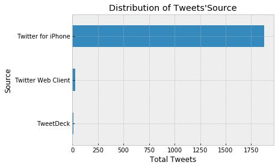

```python
plt.title("Distribution of Tweets'Source")
master_dataset.source.value_counts().sort_values().plot(kind ='barh')
plt.xlabel('Total Tweets')
plt.ylabel('Source');
```

```python
# percentage of sources
master_dataset.source.value_counts() / master_dataset.source.value_counts().sum()
```

```
Twitter for iPhone    0.980157
Twitter Web Client    0.014621
TweetDeck             0.005222
Name: source, dtype: float64
```

It is clear from the above that Twitter app in Iphone has the most share **98%** which is better explained by :

> - The ease of use to take a shot for a dog from the app
> - The high resolution of cameras.
- Nice to mention here that around 91 records of **Vine** source was omitted in the cleaning process as they contain no jpg_url and those counts for around only *5%* so the above insight is still valid.

## `2` Which is the most popular day/month to post a dog photo?

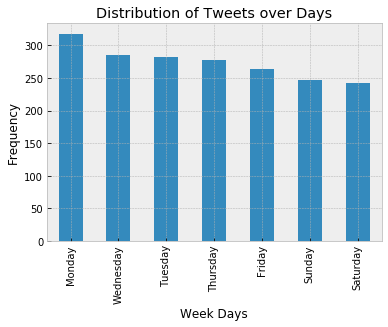

```python
master_dataset.day_name.value_counts().plot('bar')
plt.title("Distribution of Tweets over Days")
plt.xlabel('Week Days')
plt.ylabel('Frequency');
```

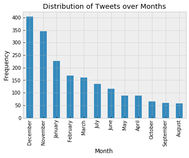

```python
master_dataset.month.value_counts().plot('bar')
plt.title("Distribution of Tweets over Months")
plt.xlabel('Month')
plt.ylabel('Frequency');
```

- It is quiet clear that people tend to post their dogs photos in Mondy/ December
  > - Interestingly, most day is Mondy, may indicate that most of followers is out of stress (may be not workers)
  > - The top month is December may intrepreted as the time of Christmas and New Year vacations, so people tends to go out with their dogs and take shots
  > - These interpretations needs more data and investigation to be confirmed

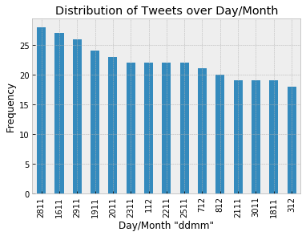

```python
# select the month and day from timestamp e.g 01/07 will be 107
master_dataset.timestamp.apply(lambda x:  x.day*100 + x.month ).value_counts().sort_values(ascending =False)[:15].plot('bar')
plt.title("Distribution of Tweets over Day/Month")
plt.xlabel('Day/Month "ddmm"')
plt.xticks(rotation = 90)
plt.ylabel('Frequency');
```

> - Viola ! It's quiet clear now , The most common Day/Month in our sample dataset indicate that most posts related to the end of November , which is matching with **Thanksgiving** Holidays, as it comes at the the Fourth Thursday of November after that **Black Fridays** which is also a holiday

## `3` Which is the most common dog name?

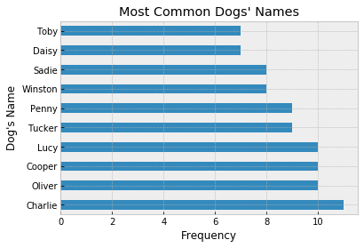

```python
# rank the names frequency in a descending order
master_dataset.dog_name.value_counts().sort_values(ascending =False)[:10].plot('barh')
plt.title("Most Common Dogs' Names")
plt.xlabel('Frequency')
plt.ylabel("Dog's Name");
```

- It is obvious here, that most used dog name in our sample is Charlie, followed by Oliver and Lucy.!
  > - May be that people tend to use real names for their dogs

## `4` What is the most common dog stage?

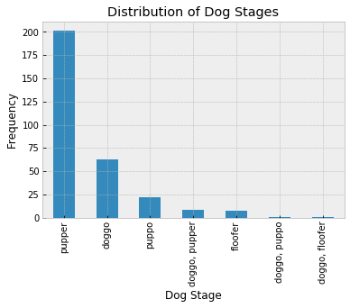

```python
# select the dog_ stage frequencies
master_dataset.dog_stage.value_counts().plot('bar')
plt.title("Distribution of Dog Stages")
plt.xlabel('Dog Stage')
plt.ylabel('Frequency');
```

- As per the dogotionary Pupper is : a small doggo, here Pupper is the most common dog stage in our dataset
- This may be due to dogs at this stage/age prefered by owners.

> **Caveats:** We need to note that some values for the dog stage is missed may be because not known by the account itself and/or the dog's owner

## `5` How do @WeRateDogs account rate dogs?

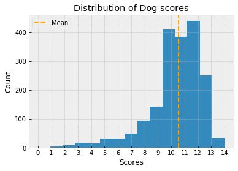

```python
# histogram for the dog score
master_dataset.dog_score.hist(bins=15)
plt.title('Distribution of Dog scores')
plt.xlabel('Scores')
plt.ylabel('Count')
plt.axvline(x= master_dataset.dog_score.mean(),color='orange', linestyle='--',label ='Mean')
plt.xticks(np.arange(15))
plt.legend(loc=0);
```

```python
# descriptive stats
master_dataset.dog_score.describe()
```

```
count    1915.000000
mean     10.547666
std      2.175686
min      0.000000
25%      10.000000
50%      11.000000
75%      12.000000
max      14.000000
Name: dog_score, dtype: float64
```

- We can notice from the above plot that the most frequent score is arround 12, and the maximun is 14
- Although the rating system for the account is /10 but actually the average rating is 10.55!
- One of the most causes for this account poularity they tend to give higher scores i.e above 10, **Brent** was right!

## `6` Which is the most common breed?

- Note : I need to iterate here over the cleaning process to fix the name of breeds (remove underscore and titled breed names)

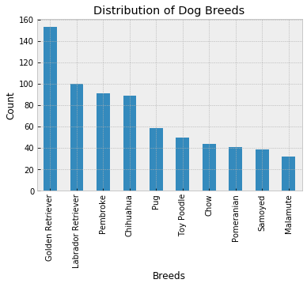

```python
# frequency for dog breeds
master_dataset.dog_breed.value_counts()[:10].plot('bar')
plt.title('Distribution of Dog Breeds')
plt.xlabel('Breeds')
plt.ylabel('Count');
```

- Here, The most common breed in our sample is **Golden Retriever**

  > **Caveats:**
  > - The breeds data contains a lot of null values
  > - Also to take into consideration that this data is given by a neural network model

## `7` What is the account performance over time?

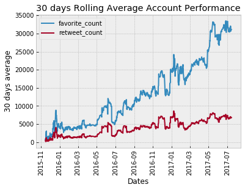

```python
# set a 30 days rolling average for favorite count
y1= master_dataset.favorite_count.rolling(window = 30).mean()
# set a 30 days rolling average for retweet count
y2= master_dataset.retweet_count.rolling(window = 30).mean()
x = master_dataset.timestamp
plt.plot(x,y1)
plt.plot(x,y2)
plt.xticks(rotation = 90)
plt.title('30 days Rolling Average Account Performance')
plt.xlabel('Dates')
plt.ylabel('30 days average')
plt.legend(loc=0);
```

It's quiet clear here that the @WeRateDogs account is getting more popular overtime, noticed by the increase number of likes(favorite_count)

- Also it is quiet clear that folowers tends to like more than to retweet

## `8` Who is the top retweeted and/or favorite dog?

```python
def get_photo(param):
    """
    get photo and numbers of the top of param after sorting descendingly.

    INPUT: param as one of our dataset columns
    ----------------------------------------------
    OUTPUT:
            image saved from the jpg_url link
            print out the numbers for the top
    """
    winner = master_dataset.loc[master_dataset[param].sort_values(ascending =False).index[0]]
    r = requests.get(winner['jpg_url'])
    i =Image.open(BytesIO(r.content))
    i.save('.\images/'+f'top_of_{param}.jpg')
    print(f'Top {param} is: {winner[param]}')
```

```python
get_photo('favorite_count')
```

```
Top favorite_count is: 132810
```

```python
get_photo('retweet_count')
```

```
Top retweet_count is: 79515
```

[output not shown]

```python
# final winner
# get the winner who has the largest retweet_count and the favorite_count
max_retweet , max_favorite = master_dataset.favorite_count.groupby(master_dataset['retweet_count']).value_counts().\
                            sort_values(ascending=False).index[0]

winner = master_dataset.query('favorite_count == @max_favorite & retweet_count == @max_retweet')

r = requests.get(winner['jpg_url'].item())
i =Image.open(BytesIO(r.content))
i.save('.\images\winner.jpg')
# prin the final result
print(f"No of retweets is : {winner['retweet_count'].item()}, \nNo of favorite_count is {winner['favorite_count'].item()}")
```

```
No of retweets is : 79515,
No of favorite_count is 131075
```

```python
# winner dog-score
winner['dog_score']
```

```
768    13.0
Name: dog_score, dtype: float64
```

[figure not shown]

This awesome dogs prove his capability to swim in a pool so, he catched the attenion of followers either by retweet or give him a like

## `9` How @WeRateDogs account write their posts? (DogCloud)

```python
text = master_dataset.text.to_string(index =False).replace('/','').strip()
```

```python
#select the text
def wordzcloud(text):
    #text =df_sql.review[0]

    # choose the mask from a google dog pictures
    url = 'https://cdn.pixabay.com/photo/2013/11/28/11/32/dog-220324_960_720.jpg'
    r = requests.get(url)
    mask = np.array(Image.open(BytesIO(r.content)))

    # set stopwords
    stopwords = ('This','and','is','the','to')#set(STOPWORDS)
    # set other parameters
    wc = WordCloud(background_color= 'white',
                  mask = mask,
                  stopwords=stopwords,
                  max_words=100,
                  contour_color='blue')
    # generate the word cloud
    wc.generate(text)
    # show the image
    wc.to_file('.\images\dog_cloud.jpg')
    return wc.to_image()
```

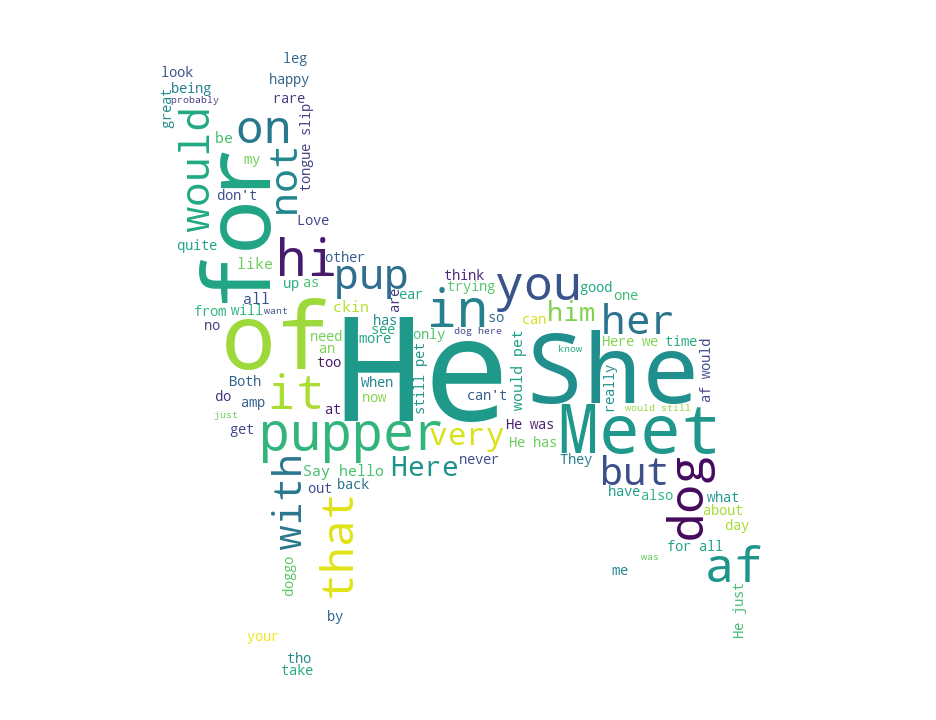

```python
# generate the word cloud from text
wordzcloud(text)
```

> Intersting Notes Here:
> - The admin uses friendly words as Meet, Say Hello, Here ,love,like...
> - The appearance of He is more than She which indicates the gender of dog is more for male dogs
> - The presence of Pupper dog stage is much larger than doggo, which is matching with my analysis.

## Resources

- [Stackoverflow : delete list of rows in pandas](https://stackoverflow.com/questions/14661701/how-to-drop-a-list-of-rows-from-pandas-dataframe)
- [DOCS: Get the name of the day in pandas](http://pandas.pydata.org/pandas-docs/stable/reference/api/pandas.Series.dt.day_name.html)
- [Conditional replace](https://stackoverflow.com/questions/21608228/conditional-replace-pandas)
- Outliers :Independence Day)
- [Outliers: Snoop dogg](https://en.wikipedia.org/wiki/Snoop_Dogg)
- [Holidays](https://www.edarabia.com/school-holidays-united-states/)

A work by [Mohamed Hindam](https://github.com/hindamosh/)

*hindamosh@gmail.com*